# An R Markdown document converted from “C:/Users/Dis/Downloads/anagramm.ipynb”

## Мета-дата

Condition_y = тип наводки (1 - активная, 2 - пассивная) type_intrusion = тип интрузия (0 - не было интрузии, 1 - не целевая интрузиция, 2 - целевая интрузция)

## Загрузка пакетов

```r
#install.packages('lmerTest')
#install.packages('rstatix')
#install.packages('sjPlot')
#install.packages('Rmisc')
#install.packages('ggeffects')
```

```r
library(tidyverse)
library(dplyr)
library(readxl)
library(httr)
library(lmerTest)
library(rstatix)
library(ggeffects)
```

```r
#library(sjPlot)
#library(Rmisc)
```

## Скачка файлов

```r
RESPONSES_LINK <- "https://docs.google.com/spreadsheets/d/1mTmC2Nc1BmPzs44BlvgIz7vEq1AEaXT2i-aXTTNphKI/export?format=xlsx"
GET(RESPONSES_LINK, write_disk(RESPONSES_PATH <- tempfile(fileext = ".xlsx")))
```

```
## Response [https://doc-10-7c-sheets.googleusercontent.com/export/54bogvaave6cua4cdnls17ksc4/lain6ddl5aq1lc0so1riuiqitc/1734436105000/100665055054225576803/*/1mTmC2Nc1BmPzs44BlvgIz7vEq1AEaXT2i-aXTTNphKI?format=xlsx]
##   Date: 2024-12-17 11:48
##   Status: 200
##   Content-Type: application/vnd.openxmlformats-officedocument.spreadsheetml.sheet
##   Size: 858 kB
## <ON DISK>  C:\Users\ALLAHV~1.VM\AppData\Local\Temp\RtmpqUpofu\file2b901217509e.xlsx
```

```r
SUBJECT_INFO_LINK <- "https://docs.google.com/spreadsheets/d/1C3FYRXbbDBguM9a5sU8gUIxMXKnjvzqVSZGseWlx-x4/export?format=csv"
GET(SUBJECT_INFO_LINK, write_disk(SUBJECT_INFO_PATH <- tempfile(fileext = ".xlsx")))
```

```
## Response [https://doc-0g-7c-sheets.googleusercontent.com/export/54bogvaave6cua4cdnls17ksc4/8m6raujsqi3bfat8s4g3hqgec4/1734436110000/100665055054225576803/*/1C3FYRXbbDBguM9a5sU8gUIxMXKnjvzqVSZGseWlx-x4?format=csv]
##   Date: 2024-12-17 11:48
##   Status: 200
##   Content-Type: text/csv
##   Size: 30.4 kB
## <ON DISK>  C:\Users\ALLAHV~1.VM\AppData\Local\Temp\RtmpqUpofu\file2b902aa47d6c.xlsx
```

```r
PART_ONE_PATH <- "data/main/offline/"
PART_TWO_PATH <- "data/main/online.csv"
BASE_COUNT_PROB <- 78
```

## Загрузка ответов

```r
responses <- NULL

sheets <- excel_sheets(RESPONSES_PATH)
sheets <- sheets[! sheets %in% c('шаблон', 'исключенный')]
for (item in sheets) {
  if(is.null(responses)) {
    responses <- read_excel(RESPONSES_PATH, sheet = item)
    next
  }
  responses <- bind_rows(responses, read_excel(RESPONSES_PATH, sheet = item))
}
responses$dropout_1 <- responses$`Отсев 1 этап`
responses$dropout_2 <- responses$`Отсев 2 этап`
responses$prob_counter <- responses$`Номер_пробы_(этап_1)...2` %>% as.numeric()
print(responses)
```

```
## # A tibble: 9,207 × 23
##       ID `Номер_пробы_(этап_1)...2` `Ответ_(этап_1)` `Комментарии_(этап_1)`
##    <dbl>                      <dbl> <chr>            <chr>
##  1     1                          1 <NA>             <NA>
##  2     1                          2 <NA>             <NA>
##  3     1                          3 <NA>             <NA>
##  4     1                          4 <NA>             <NA>
##  5     1                          5 <NA>             <NA>
##  6     1                          6 <NA>             <NA>
##  7     1                          7 <NA>             <NA>
##  8     1                          8 <NA>             <NA>
##  9     1                          9 <NA>             <NA>
## 10     1                         10 <NA>             <NA>
## # ℹ 9,197 more rows
## # ℹ 19 more variables: `Блок_(этап_1)` <dbl>, `Номер_пробы_(этап_1)...6` <dbl>,
## #   `Ответ_(этап_2)` <chr>, `Версии_(этап_2)` <chr>, `Блок_(этап_2)` <dbl>,
## #   `Комментарии_(этап_2)` <chr>, `Количество нет 1-1` <dbl>,
## #   `Количество нет 1-2` <dbl>, `Количество нет 1-3` <dbl>,
## #   `Количество нет 2-1` <dbl>, `Количество нет 2-2` <dbl>,
## #   `Количество нет 2-3` <dbl>, `Процент количества нет_1` <dbl>, …
```

## Загрузка данных об испытуемых

```r
subject_ifno <- read_csv(SUBJECT_INFO_PATH)
```

```
## ──────────────────────────────────────────────────────── Delimiter: "," chr
## (20): ФИО, Дата рождения, Уровень образования, Дата проведения, Пол, Тел... dbl
## (5): ID, Возраст, Лист на 1-ом этапе, Последовательность, Исключение lgl (3):
## ...18, ...24, ...25
```

```r
subject_ifno <- subject_ifno %>% filter(!is.na(ID))
subject_ifno$age <- subject_ifno$Возраст
subject_ifno$date <- subject_ifno$`Дата проведения`
subject_ifno$list <- subject_ifno$`Лист на 1-ом этапе`
subject_ifno$sequence <- subject_ifno$Последовательность
subject_ifno$group <- subject_ifno$Группа
subject_ifno$researcher <- subject_ifno$Экспериментатор
subject_ifno$coomment <- subject_ifno$Комментарии
subject_ifno$exclude <- subject_ifno$Исключение
subject_ifno$strategy <- subject_ifno$Стратегия
subject_ifno$suppression_of_a_tip <- subject_ifno$`Использование / подавление наводки`
subject_ifno[is.na(subject_ifno$exclude),]$exclude <- 0
subject_ifno <- subject_ifno %>% select(ID, age, date, list, sequence, group, researcher, coomment, exclude, strategy, suppression_of_a_tip)
print(subject_ifno)
```

```
## # A tibble: 117 × 11
##       ID   age date     list sequence group researcher coomment exclude strategy
##    <dbl> <dbl> <chr>   <dbl>    <dbl> <chr> <chr>      <chr>      <dbl> <chr>
##  1     1    29 16.08.…    NA      123 конт… Илья       Сообщил…       0 <NA>
##  2     2    23 20.08.…    NA      132 конт… Илья       <NA>           0 <NA>
##  3     3    40 20.08.…    NA      213 конт… Илья       <NA>           0 <NA>
##  4     4    23 20.08.…    NA      231 конт… Илья       Уставша…       1 <NA>
##  5     5    22 23.08.…    NA      312 конт… Илья       <NA>           0 <NA>
##  6     6    31 25.08.…    NA      321 конт… Илья       Из Ново…       0 <NA>
##  7     7    24 10.09.…    NA      123 конт… Илья       Гипреве…       1 <NA>
##  8     8    20 13.09.…    NA      132 конт… Илья       Самодиа…       1 <NA>
##  9     9    23 17.09.…     1      123 эксп  Диана      <NA>           0 не смот…
## 10    10    30 18.09.…     2      132 эксп  Костя      На 1 эт…       0 <NA>
## # ℹ 107 more rows
## # ℹ 1 more variable: suppression_of_a_tip <chr>
```

## #Загрузка данных 1 этапа

```r
# первый
load_file_1 <- function(x) {
  if (str_detect(x, 'csv')) {
    df <- read_csv(str_c(PART_ONE_PATH, x),
                   col_types = cols(.default = col_character()))
    df$ID <- x %>% str_replace(".csv", "")
    return(df)

  }
}

part_1 <- do.call('bind_rows',
                 PART_ONE_PATH %>%
                   list.files() %>%
                   lapply(load_file_1)
)
part_1 <- part_1 %>% merge(subject_ifno)

 # Предварительный анализ

part_1$Target.RT <- as.numeric(part_1$Target.RT)
part_1$Accuracy <- as.numeric(part_1$Accuracy)
part_1$Q1Aha.RESP <- as.numeric(part_1$Q1Aha.RESP)
part_1$prob_counter <- part_1$prob_counter %>% as.numeric()
part_1$ID <- part_1$ID %>% as.numeric()
```

## Соединение таблицы с первым этапом с таблицей с ответами

```r
part_1 %>%
  inner_join(responses, by = c('ID', 'prob_counter')) -> part_1

# пересчёт данных о правильности и аккуратности
part_1$Answer.Resp <- part_1$`Ответ_(этап_1)`
part_1$Accuracy <- (tolower(part_1$Answer.Resp) == tolower(part_1$Answer.Corr)) %>% as.numeric()
part_1$Accuracy_alph <- c('wrong', 'correct')[part_1$Accuracy + 1]
part_1$Condition <- part_1$Condition_y
```

## Загрузка данных 2 этапа

```r
# загрузка
part_2 <- read_csv(PART_TWO_PATH)
# добавления ID во все пробы
part_2 <- part_2 %>%
            left_join(
              part_2 %>%
                group_by(code) %>%
                summarise(
                  ID = id[sender == "Анкета"],
                  age = age[sender == "Анкета"],
                  group = группа[sender == "Анкета"]
                ),
              by = 'code'
            )
part_2 <- part_2 %>% filter(!is.na(i) & !is.na(counter))
# Добавляем счётчик
block <- 26 * (part_2$i %>% as.numeric() - 1 )
part_2$prob_counter2  <- (part_2$counter %>% as.numeric() + 1) + block
# корректировка некорректно подписанного ID
part_2[part_2$code == "6649fb945646826d30607adb", ]$ID <- 114

# добавляем так чтобы вся информация была по одной пробе
part_2 %>%
  filter(i != 0) %>%
  group_by(ID, prob_counter2) %>%
  summarise(
    # время овтета
    Target.RT2 = duration[sender == "Анаграмма *код"],
    # как завершился экран - по таймауту ил инет
    ended_on = ended_on[sender == "Анаграмма *код"],
    # используемая последовательность
    block_seq = block_seq[sender == "Ответ *код"],
    # какой сейчас блок
    run = df_RUN[sender == "Ответ *код"],
    # правильный ответ на анаграмму
    Answer.Corr2 = df_анаграмма[sender == "Ответ *код"],
    # наводка
    tip = df_наводка[sender == "Ответ *код"],
    seq = seq[sender == "Ответ *код"],
    # блок по счёту
    counter_block = i[sender == "Ответ *код"]
  ) %>%
  ungroup() -> part_2
```

```
## argument.
```

```r
# делаем вид обозначение последовательности такой же как в первом этапе
part_2$block_seq <- part_2$block_seq %>% str_replace_all("0", "")
part_2$block_seq <- part_2$block_seq %>% str_replace_all(",", "")
part_2[part_2$ended_on == "timeout",]$Target.RT2 <- 0
part_2$Target.RT2 <- part_2$Target.RT2 %>% round(0)
```

```r
problems()
```

## Добавление ответов ко 2 этапу и данными об добровольцах

```r
part_2 <- part_2 %>% merge(subject_ifno)

part_2 %>%
  inner_join(responses, by = c('ID', 'prob_counter2' = 'prob_counter')) -> part_2
part_2$Answer.Resp2 <- part_2$`Ответ_(этап_2)`
part_2$Answer.Vers <- part_2$`Версии_(этап_2)`

part_2 %>% select(ID, prob_counter2, Target.RT2, block_seq, run, Answer.Corr2, Answer.Resp2, Answer.Vers, tip, counter_block, age, date, list, sequence, group, researcher, exclude) -> part_2
part_2$Accuracy2 <- (tolower(part_2$Answer.Corr2) == tolower(part_2$Answer.Resp2)) %>% as.numeric()
```

## Отсев для первой гипотезы (время реакции)

критерии отсевва: * Время реакции более 20 секунд, поскольку далее не регистрировалось нажатие как референтная точка конца отсчёта времени. * Ответы быстрее 200мс (?) и всё, что выходит за пределы трёх стандартных отклонений. * Неправильность ответа

```r
part_1$dropout_1h <- 0

#подсчёт минимального и максимального времени реакции для каждого человека
part_1 <- part_1 %>%
          left_join(part_1 %>%
                      filter(Target.RT > 0) %>%
                      group_by(ID) %>%
                      summarise(
                        min_rt = mean(Target.RT) - 3 * sd(Target.RT),
                        max_rt = mean(Target.RT) + 3 * sd(Target.RT)
                      ) %>%
                      ungroup() %>%
                      select(ID, min_rt, max_rt)
                    , by = 'ID')

# отсев по критериям
min_rt <- mean(part_1$Target.RT) - 3 * sd(part_1$Target.RT)
max_rt <- mean(part_1$Target.RT) + 3 * sd(part_1$Target.RT)
part_1[(
  (part_1$Target.RT < 200) |
  (part_1$Target.RT <  min_rt) |
  (part_1$Target.RT > max_rt) |
  (part_1$Accuracy == 0)
), "dropout_1h"] <- 1
```

## Отсев по кокнертным пробам

```r
part_1[!is.na(part_1$dropout_1) & part_1$dropout_1 == 1, ]$dropout_1h <- 1
```

## Отсев по людям

```r
if(nrow(part_1[!is.na(part_1$exclude) & part_1$exclude == 1, ]) > 0)
  part_1[!is.na(part_1$exclude) & part_1$exclude == 1, ]$dropout_1h <- 1
```

```r
part_1$dropout_1h  %>%  table()
```

```
## .
##    0    1
## 2540 1906
```

## Отсев для 1 гипотезы (правильность работы)

```r
part_1$dropout_1_2h <- 0
#part_1[(
#  (part_1$Target.RT == 0)
#), "dropout_1_2h"] <- 1
```

## Отсев по людям

```r
part_1[!is.na(part_1$dropout_1) & part_1$dropout_1 == 1, ]$dropout_1_2h <- 1
```

```r
if(nrow(part_1[!is.na(part_1$exclude) & part_1$exclude == 1, ]) > 0)
  part_1[!is.na(part_1$exclude) & part_1$exclude == 1, ]$dropout_1_2h <- 1
```

```r
part_1$dropout_1_2h  %>%  table()
```

```
## .
##    0    1
## 4327  119
```

## Отсев для 2 гипотезы

Критерии: * Неправильный ответ на анаграмму. * Была нажата кнопка “не решил” в Ага!, но анаграмма при этом решена, так как это ошибка испытуемого.

```r
part_1$dropout_2h <- 0
part_1[(
  (part_1$Accuracy == 0) |
  (part_1$Q1Aha.RESP == 3)
), "dropout_2h"] <- 1

part_1 <- part_1 %>%
          left_join(part_1 %>%
                      group_by(ID) %>%
                      summarise(
                        aha_per = ((sum(Q1Aha.RESP[Accuracy == 1 & Q1Aha.RESP == 1])) / sum(Accuracy) * 100)  %>% round(0),
                      ) %>%
                      ungroup() %>%
                      select(ID, aha_per)
                    , by = 'ID')
```

Отсев людей, где ага было больше 90 и меньше 10 процентов

```r
part_1[(
  (part_1$aha_per < 10) |
  (part_1$aha_per > 90)
), "dropout_2h"] <- 1
```

## Отсев по людям

```r
part_1[!is.na(part_1$dropout_1) & part_1$dropout_1 == 1, ]$dropout_2h <- 1
```

```r
if(nrow(part_1[!is.na(part_1$exclude) & part_1$exclude == 1, ]) > 0)
  part_1[!is.na(part_1$exclude) & part_1$exclude == 1, ]$dropout_2h <- 1
```

```r
part_1$dropout_2h  %>%  table()
```

```
## .
##    0    1
## 2282 2164
```

```r
part_2$dropout_3h %>% table()
```

```
## < table of extent 0 >
```

## Соединение первого и второго этапа

[output not shown]

```r
part_2$Answer.Corr <-part_2$Answer.Corr2
part_2 %>% left_join(part_1, by = c('ID', 'Answer.Corr')) -> full_data
full_data$Target.RT_corr <- full_data$Target.RT + 2000
full_data$block_id <- str_replace(full_data$run, "Run", "") %>% as.numeric()
full_data$session <- full_data$counter_block
full_data %>% select(
  ID,
  group.x,
  prob_counter,
  prob_counter2,
  Target,
  Condition,
  tip,
  Answer.Corr,
  Target.RT,
  Target.RT_corr,
  Answer.Resp,
  Accuracy,
  Target.RT2,
  Answer.Resp2,
  Answer.Vers,
  Accuracy2,
  Q1Aha.RESP,
  Q1Aha.RESP_alph,
  DataFile.Basename,
  Letters_y,
  List_y,
  age.x,
  date.x,
  sequence.x,
  block_id,
  block_seq,
  session,
  researcher.x,
  exclude.x,
  dropout_1,
  dropout_2,
  dropout_1h,
  dropout_1_2h,
  dropout_2h,
  strategy,
  suppression_of_a_tip
) -> full_data
full_data$ID %>% unique() %>% length()
```

```
## [1] 113
```

## добавление столбика интрузия

```r
# подготовка данных к анализу интрузий
full_data$Answer.Vers <- full_data$Answer.Vers  %>% str_replace_all(" ", "")
full_data$cue <- full_data$tip
# подсчёт количества интрузий
full_data$ver_count <- str_count(full_data$Answer.Vers, ",") + 1
# чек интрузий
full_data$intrusion <- apply(full_data, 1, function(x) {
  # выделяем список версий
  y_list <- unlist(str_split(x['Answer.Vers'], ","))
  # смотрим есть ли слово в этом списке
  return(x['cue'] %in% y_list)
}) %>% as.numeric()

# поиск целевых и нецелевых интрузий
nontarget_intrusion_filt <- (full_data$intrusion == 1 & !is.na(full_data$Condition) & full_data$Condition == 2)
target_intrusion_filt <- (full_data$intrusion == 1 & !is.na(full_data$Condition) & full_data$Condition == 1)

#заполнение типа интрузий
full_data$type_intrusion <- 0
full_data[nontarget_intrusion_filt, ]$type_intrusion <- 1
full_data[target_intrusion_filt, ]$type_intrusion <- 2

# заполнение переменной версия как ответ
full_data$ver_as_answer <- 0
full_data[!is.na(full_data$cue), ]$ver_as_answer <- (full_data[!is.na(full_data$cue), ]$cue == full_data[!is.na(full_data$cue), ]$Answer.Resp2)  %>% as.numeric()
View(full_data %>% select(ID, cue, Answer.Vers, intrusion, type_intrusion,  ver_count, ver_as_answer))
```

частота разных типов интрузий

```r
table(full_data$type_intrusion)
```

```
##
##    0    1    2
## 8000  386  428
```

частота случаев, когда наводка в качестве ответа

```r
table(full_data$ver_as_answer)
```

```
##
##    0    1
## 8756   52
```

##Отсев 3 и 5 гипотезы (Время реакции на 2ом этапе)

```r
full_data$dropout_3h <- 0

#подсчёт минимального и максимального времени реакции для каждого человека
full_data <- full_data %>%
              left_join(full_data %>%
                          filter(group.x == "эксп") %>%
                          filter(Target.RT2 > 0) %>%
                          group_by(ID) %>%
                          summarise(
                            aha_per = ((sum(Q1Aha.RESP[Accuracy == 1 & Q1Aha.RESP == 1])) / sum(Accuracy) * 100)  %>% round(0),
                          ) %>%
                          ungroup() %>%
                          select(ID, aha_per)
                        , by = 'ID')
min_rt <- mean(full_data[full_data$group.x == "эксп", ]$Target.RT2) - 3 * sd(full_data[full_data$group.x == "эксп", ]$Target.RT2)
max_rt <- mean(full_data[full_data$group.x == "эксп", ]$Target.RT2) + 3 * sd(full_data[full_data$group.x == "эксп", ]$Target.RT2)
# отсев по критериям
full_data[(
  (full_data$group.x == "эксп") & (
  (full_data$Target.RT2 < 200) |
  (full_data$Target.RT2 < min_rt) |
  (full_data$Target.RT2 > max_rt) |
  (full_data$aha_per < 10) |
  (full_data$aha_per > 90) |
  (full_data$Q1Aha.RESP == 3) |
  (full_data$Accuracy == 0) |
  (full_data$Accuracy2 == 0)
  )
), "dropout_3h"] <- 1
```

Отсев по людям

```r
full_data[!is.na(full_data$dropout_1) & full_data$dropout_1 == 1, ]$dropout_3h <- 1
```

```r
if(nrow(full_data[!is.na(full_data$exclude) & full_data$exclude == 1, ]) > 0)
  full_data[!is.na(full_data$exclude) & full_data$exclude == 1, ]$dropout_3h <- 1
```

```r
full_data$dropout_3h %>% table()
```

```
## .
##    0    1
## 6057 2757
```

Сохранение данных

```r
write_csv(full_data, 'full_data.csv')
```

## Формирование сводной таблицы

```r
full_data %>% filter(group.x == "эксп") %>%  select(dropout_1h) %>%  table()
```

```
## dropout_1h
##    0    1
## 2459 1753
```

```r
# сводная таблица по первому этапу
full_data %>%
  filter(group.x == "эксп") %>%
  group_by(ID) %>%
  summarise(mean_rt = mean(Target.RT[dropout_1h == 0]) ,
            sd_rt = sd(Target.RT[dropout_1h == 0]) %>% round(0),
            min_rt = min(Target.RT[dropout_1h == 0]),
            max_rt = max(Target.RT[dropout_1h == 0]),
            right = ((sum(Accuracy[dropout_1_2h == 0]) / BASE_COUNT_PROB) * 100) %>% round(0) %>% str_c("%"),
            aha = ((sum(Q1Aha.RESP[dropout_2h == 0 & Q1Aha.RESP == 1])) / sum(Accuracy) * 100)  %>% round(0)  %>% str_c("%"),
            list = first(List_y),
            sequence = first(sequence.x),
            researcher = first(researcher.x)
            ) %>%
  write_csv('first_means.csv')
```

```r
# сводная таблица по второму этапу
full_data %>%
  group_by(ID, group.x) %>%
  summarise(mean_rt = mean(Target.RT2) ,
            sd_rt = sd(Target.RT2) %>% round(0),
            min_rt = min(Target.RT2),
            max_rt = max(Target.RT2),
            right = ((sum(Accuracy2) / BASE_COUNT_PROB) * 100) %>% round(0) %>% str_c("%"),
            list = first(List_y),
            sequence = first(sequence.x),
            researcher = first(researcher.x)
            ) %>%
  write_csv('second_means.csv')
```

```
## argument.
```

```r
sd(full_data$age.x)
```

```
## [1] 4.236378
```

# Гипотеза 1

При решении анаграмм с активной наводкой (короткое слово внутри анаграммы) у испытуемых будет возникать эффект фиксированности, что проявится в снижении точности и замедлении решения на первом этапе.

## Время реакции

только пробы, в которых не было таймаута, тест на нормальность

## Анализ времени реакции

### Анализ средних значений

```r
# нормальность
full_data %>%
  filter(group.x == "эксп" & dropout_1h == 0) %>%
  group_by(ID) %>%
  summarise(rt = mean(Target.RT[Condition == "1"]) - mean(Target.RT[Condition == "2"])) %>%
  ungroup() %>%
  rstatix::shapiro_test(rt)
```

```
## # A tibble: 1 × 3
##   variable statistic     p
##   <chr>        <dbl> <dbl>
## 1 rt           0.975 0.318
```

```r
#  т тест
full_data %>%
  filter(group.x == "эксп" & dropout_1h == 0) %>%
  group_by(ID, Condition) %>%
  summarise(rt = mean(Target.RT)) %>%
  ungroup() %>%
  rstatix::t_test(rt ~ Condition, paired = TRUE, alternative = "two.sided")
```

```
## argument.
```

```
## # A tibble: 1 × 8
##   .y.   group1 group2    n1    n2 statistic    df     p
## * <chr> <chr>  <chr>  <int> <int>     <dbl> <dbl> <dbl>
## 1 rt    1      2         54    54     0.318    53 0.752
```

```r
# кохен
full_data %>%
  filter(group.x == "эксп" & dropout_1h == 0) %>%
  group_by(ID, Condition) %>%
  summarise(rt = mean(Target.RT)) %>%
  ungroup() %>%
  rstatix::cohens_d(rt ~ Condition, paired = TRUE)
```

```
## argument.
```

```
## # A tibble: 1 × 7
##   .y.   group1 group2 effsize    n1    n2 magnitude
## * <chr> <chr>  <chr>    <dbl> <int> <int> <ord>
## 1 rt    1      2       0.0432    54    54 negligible
```

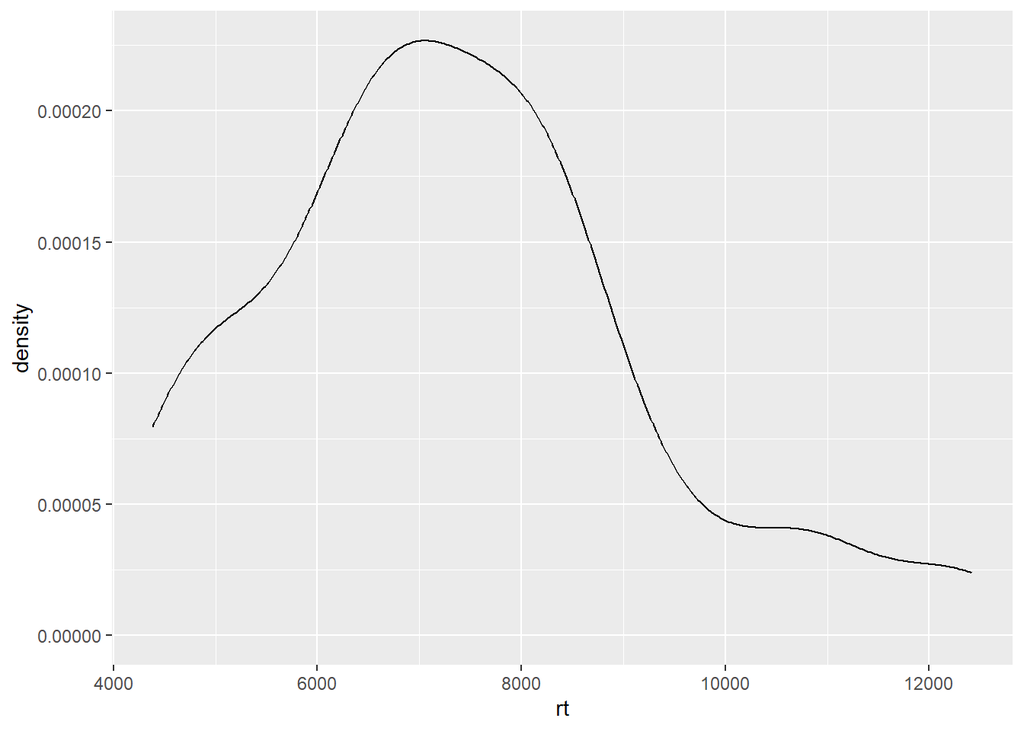

```r
#график по всему
full_data %>%
  filter(group.x == "эксп" & dropout_1h == 0) %>%
  group_by(ID) %>%
  summarise(rt = mean(Target.RT)) %>%
  ungroup() %>%
  ggplot(aes(rt))+
  geom_density()
```

```
## argument.
```

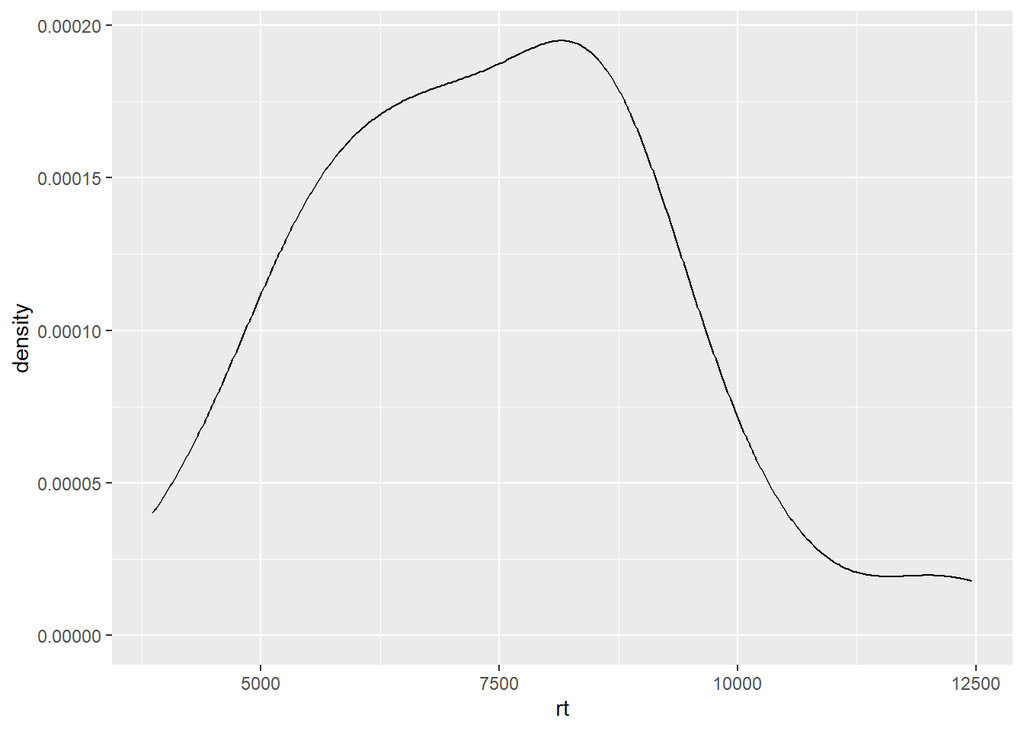

```r
#график условие - 1
full_data %>%
  filter(group.x == "эксп" & dropout_1h == 0 & Condition == 1) %>%
  group_by(ID, Condition) %>%
  summarise(rt = mean(Target.RT)) %>%
  ungroup() %>%
  ggplot(aes(rt))+
  geom_density()
```

```
## argument.
```

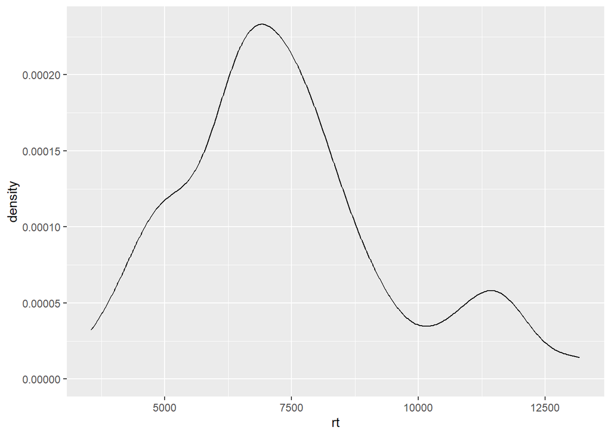

```r
full_data %>%
  filter(group.x == "эксп" & dropout_1h == 0 & Condition == 2) %>%
  group_by(ID, Condition) %>%
  summarise(rt = mean(Target.RT)) %>%
  ungroup() %>%
  ggplot(aes(rt))+
  geom_density(alpha=0.5)
```

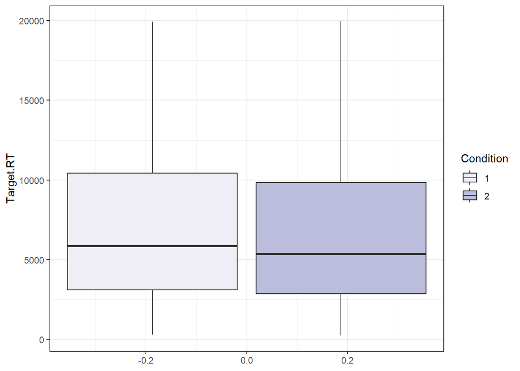

```r
full_data %>%
  filter(group.x == "эксп" & dropout_1h == 0) %>%
  ggplot(aes(y=Target.RT, fill=Condition))+
  geom_boxplot()+
  theme_bw()+
    scale_fill_brewer(palette="Purples")
```

```r
full_data %>%
  filter(group.x == "эксп" & dropout_1h == 0) %>%
  group_by(Condition) %>%
  summarise(rt = mean(Target.RT))
```

```
## # A tibble: 2 × 2
##   Condition    rt
##   <chr>     <dbl>
## 1 1         7151.
## 2 2         6876.
```

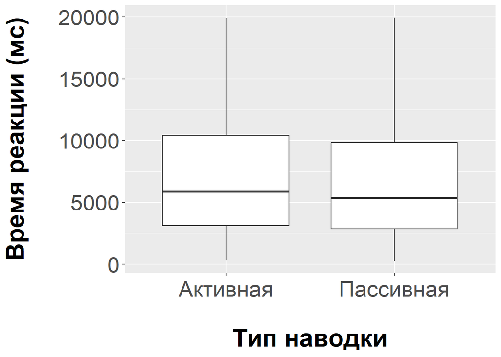

```r
full_data %>%
  filter(group.x == "эксп" & dropout_1h == 0) %>%
  ggplot(aes(Condition, Target.RT)) +
  geom_boxplot()+
  xlab("\nТип наводки")+
  ylab('Время реакции (мс)\n')+
  scale_x_discrete(labels = c('1' = 'Активная', '2' = 'Пассивная')) +
  theme(axis.title.x = element_text(face="bold",
                                    colour="#000000", size=25),
        axis.text.x  = element_text(vjust=0.5, size=22))+
  theme(axis.title.y = element_text(face="bold",
                                    colour="#000000", size=25),
        axis.text.y  = element_text(vjust=0.5, size=22))
```

### смешанные модели

```r
full_data$Letters_y <- full_data$Letters_y %>% as.numeric() %>% as.factor()
full_data$ID <- full_data$ID %>% as.factor()
full_data$List_y <- full_data$List_y %>% as.factor()
full_data$anagram_answ <- full_data$Answer.Corr %>% as.factor()
```

```r
model1 <- lmer(
                Target.RT ~ Condition + (1|ID),
                full_data %>% filter(group.x == "эксп" & dropout_1h == 0),
                REML = FALSE
              )
model1 %>% summary()
```

```
## Linear mixed model fit by maximum likelihood . t-tests use Satterthwaite's
##   method [lmerModLmerTest]
## Formula: Target.RT ~ Condition + (1 | ID)
##    Data: full_data %>% filter(group.x == "эксп" & dropout_1h == 0)
##
##      AIC      BIC   logLik deviance df.resid
##  48658.2  48681.4 -24325.1  48650.2     2455
##
## Scaled residuals:
##     Min      1Q  Median      3Q     Max
## -1.6429 -0.7674 -0.2913  0.5901  3.1255
##
## Random effects:
##  Groups   Name        Variance Std.Dev.
##  ID       (Intercept)  2552173 1598
##  Residual             22009731 4691
## Number of obs: 2459, groups:  ID, 54
##
## Fixed effects:
##             Estimate Std. Error     df t value Pr(>|t|)
## (Intercept)   7399.4      256.8   67.1  28.818   <2e-16 ***
## Condition2    -214.8      189.9 2408.7  -1.131    0.258
## ---
## Signif. codes:  0 '***' 0.001 '**' 0.01 '*' 0.05 '.' 0.1 ' ' 1
##
## Correlation of Fixed Effects:
##            (Intr)
## Condition2 -0.368
```

```r
model2 <- lmer(
                Target.RT ~ Condition + (1|Letters_y) + (1|ID),
                full_data %>% filter(group.x == "эксп" & dropout_1h == 0),
                REML = FALSE
              )
model2 %>% summary()
```

```
## Linear mixed model fit by maximum likelihood . t-tests use Satterthwaite's
##   method [lmerModLmerTest]
## Formula: Target.RT ~ Condition + (1 | Letters_y) + (1 | ID)
##    Data: full_data %>% filter(group.x == "эксп" & dropout_1h == 0)
##
##      AIC      BIC   logLik deviance df.resid
##  48628.5  48657.6 -24309.3  48618.5     2454
##
## Scaled residuals:
##     Min      1Q  Median      3Q     Max
## -1.7974 -0.7534 -0.2858  0.6319  3.2805
##
## Random effects:
##  Groups    Name        Variance Std.Dev.
##  ID        (Intercept)  2705619 1645
##  Letters_y (Intercept)   361180  601
##  Residual              21659476 4654
## Number of obs: 2459, groups:  ID, 54; Letters_y, 2
##
## Fixed effects:
##             Estimate Std. Error       df t value Pr(>|t|)
## (Intercept) 7406.003    499.074    3.353  14.839 0.000356 ***
## Condition2  -208.194    188.407 2407.153  -1.105 0.269259
## ---
## Signif. codes:  0 '***' 0.001 '**' 0.01 '*' 0.05 '.' 0.1 ' ' 1
##
## Correlation of Fixed Effects:
##            (Intr)
## Condition2 -0.188
```

```r
model3 <- lmer(
                Target.RT ~ Condition + (1|ID) + (1|anagram_answ),
                full_data %>% filter(group.x == "эксп" & dropout_1h == 0),
                REML = FALSE
              )
model3 %>% summary()
```

```
## Linear mixed model fit by maximum likelihood . t-tests use Satterthwaite's
##   method [lmerModLmerTest]
## Formula: Target.RT ~ Condition + (1 | ID) + (1 | anagram_answ)
##    Data: full_data %>% filter(group.x == "эксп" & dropout_1h == 0)
##
##      AIC      BIC   logLik deviance df.resid
##  48535.9  48564.9 -24262.9  48525.9     2454
##
## Scaled residuals:
##     Min      1Q  Median      3Q     Max
## -2.2401 -0.7313 -0.2560  0.5730  3.5608
##
## Random effects:
##  Groups       Name        Variance Std.Dev.
##  anagram_answ (Intercept)  2462194 1569
##  ID           (Intercept)  3046012 1745
##  Residual                 19829801 4453
## Number of obs: 2459, groups:  anagram_answ, 78; ID, 54
##
## Fixed effects:
##             Estimate Std. Error      df t value Pr(>|t|)
## (Intercept)  7766.46     325.76   99.84  23.841   <2e-16 ***
## Condition2   -241.50     181.15 2331.06  -1.333    0.183
## ---
## Signif. codes:  0 '***' 0.001 '**' 0.01 '*' 0.05 '.' 0.1 ' ' 1
##
## Correlation of Fixed Effects:
##            (Intr)
## Condition2 -0.278
```

```r
model4 <- lmer(
                Target.RT ~ Condition + List_y + sequence.x + (1|ID) + (1|anagram_answ),
                full_data %>% filter(group.x == "эксп" & dropout_1h == 0),
                REML = FALSE)
model4 %>% summary()
```

```
## Linear mixed model fit by maximum likelihood . t-tests use Satterthwaite's
##   method [lmerModLmerTest]
## Formula: Target.RT ~ Condition + List_y + sequence.x + (1 | ID) + (1 |
##     anagram_answ)
##    Data: full_data %>% filter(group.x == "эксп" & dropout_1h == 0)
##
##      AIC      BIC   logLik deviance df.resid
##  48538.3  48578.9 -24262.1  48524.3     2452
##
## Scaled residuals:
##     Min      1Q  Median      3Q     Max
## -2.2419 -0.7296 -0.2528  0.5689  3.5705
##
## Random effects:
##  Groups       Name        Variance Std.Dev.
##  anagram_answ (Intercept)  2459284 1568
##  ID           (Intercept)  2933070 1713
##  Residual                 19831761 4453
## Number of obs: 2459, groups:  anagram_answ, 78; ID, 54
##
## Fixed effects:
##             Estimate Std. Error       df t value Pr(>|t|)
## (Intercept) 7366.357    814.779   54.970   9.041 1.83e-12 ***
## Condition2  -238.803    181.174 2329.795  -1.318    0.188
## List_y2     -456.916    503.195   49.737  -0.908    0.368
## sequence.x     2.901      3.309   49.626   0.877    0.385
## ---
## Signif. codes:  0 '***' 0.001 '**' 0.01 '*' 0.05 '.' 0.1 ' ' 1
##
## Correlation of Fixed Effects:
##            (Intr) Cndtn2 Lst_y2
## Condition2 -0.112
## List_y2    -0.308 -0.013
## sequence.x -0.869  0.006  0.012
```

```r
model0 <- lmer(
                Target.RT ~ 1 + (1|ID) + (1|Letters_y),
                full_data %>% filter(group.x == "эксп" & dropout_1h == 0),
                REML = FALSE)
```

```r
# сравнение моделей между собой
anova(model1, model2)
```

```
## Data: full_data %>% filter(group.x == "эксп" & dropout_1h == 0)
## Models:
## model1: Target.RT ~ Condition + (1 | ID)
## model2: Target.RT ~ Condition + (1 | Letters_y) + (1 | ID)
##        npar   AIC   BIC logLik deviance  Chisq Df Pr(>Chisq)
## model1    4 48658 48681 -24325    48650
## model2    5 48629 48658 -24309    48619 31.637  1  1.858e-08 ***
## ---
## Signif. codes:  0 '***' 0.001 '**' 0.01 '*' 0.05 '.' 0.1 ' ' 1
```

```r
anova(model1, model3)
```

```
## Data: full_data %>% filter(group.x == "эксп" & dropout_1h == 0)
## Models:
## model1: Target.RT ~ Condition + (1 | ID)
## model3: Target.RT ~ Condition + (1 | ID) + (1 | anagram_answ)
##        npar   AIC   BIC logLik deviance Chisq Df Pr(>Chisq)
## model1    4 48658 48681 -24325    48650
## model3    5 48536 48565 -24263    48526 124.3  1  < 2.2e-16 ***
## ---
## Signif. codes:  0 '***' 0.001 '**' 0.01 '*' 0.05 '.' 0.1 ' ' 1
```

```r
anova(model2, model3)
```

```
## Data: full_data %>% filter(group.x == "эксп" & dropout_1h == 0)
## Models:
## model2: Target.RT ~ Condition + (1 | Letters_y) + (1 | ID)
## model3: Target.RT ~ Condition + (1 | ID) + (1 | anagram_answ)
##        npar   AIC   BIC logLik deviance  Chisq Df Pr(>Chisq)
## model2    5 48629 48658 -24309    48619
## model3    5 48536 48565 -24263    48526 92.667  0
```

```r
anova(model2, model0)
```

```
## Data: full_data %>% filter(group.x == "эксп" & dropout_1h == 0)
## Models:
## model0: Target.RT ~ 1 + (1 | ID) + (1 | Letters_y)
## model2: Target.RT ~ Condition + (1 | Letters_y) + (1 | ID)
##        npar   AIC   BIC logLik deviance  Chisq Df Pr(>Chisq)
## model0    4 48628 48651 -24310    48620
## model2    5 48629 48658 -24309    48619 1.2205  1     0.2693
```

## Правильность ответов

### Процент правильных ответов

### Анализ средних значений

```r
# нормальность
full_data %>%
  filter(group.x == "эксп" & dropout_1_2h == 0) %>%
  group_by(ID, Condition) %>%
  summarise(right_per = ((sum(Accuracy) / length(Accuracy)) * 100) %>% round(0)) %>%
  ungroup() %>%
  rstatix::shapiro_test(right_per)
```

```
## argument.
```

```
## # A tibble: 1 × 3
##   variable  statistic     p
##   <chr>         <dbl> <dbl>
## 1 right_per     0.981 0.117
```

```r
# t test
full_data %>%
  filter(group.x == "эксп" & dropout_1_2h == 0) %>%
  group_by(ID, Condition) %>%
  summarise(right_per = ((sum(Accuracy) / length(Accuracy)) * 100) %>% round(0)) %>%
  ungroup() %>%
  rstatix::wilcox_test(right_per ~ Condition, paired = TRUE, alternative = "two.sided")
```

```
## argument.
```

```
## # A tibble: 1 × 7
##   .y.       group1 group2    n1    n2 statistic     p
## * <chr>     <chr>  <chr>  <int> <int>     <dbl> <dbl>
## 1 right_per 1      2         54    54       604 0.874
```

### График

```
## argument.
```

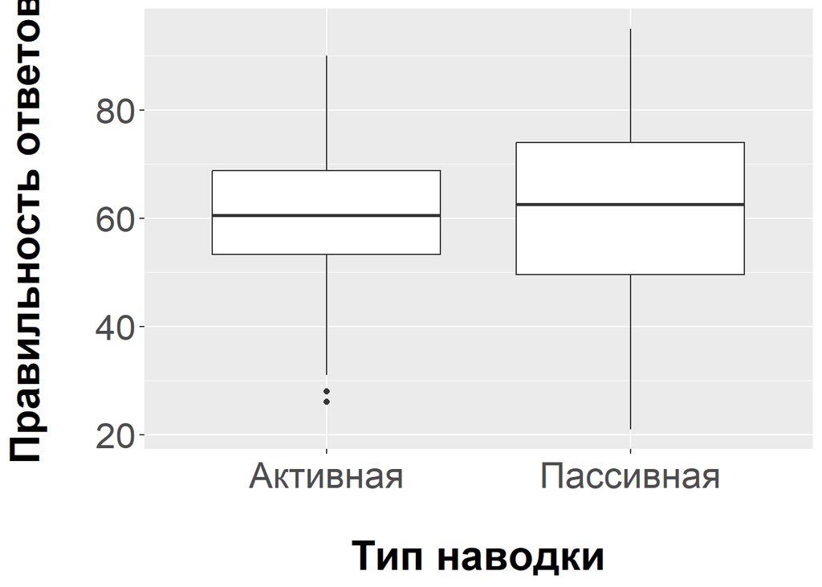

```r
full_data %>%
  filter(group.x == "эксп" & dropout_1_2h == 0) %>%
  group_by(ID, Condition) %>%
  summarise(right_per = ((sum(Accuracy) / length(Accuracy)) * 100) %>% round(0)) %>%
  ungroup() %>%
  ggplot(aes(Condition, right_per)) +
  geom_boxplot()+
  xlab("\nТип наводки")+
  ylab('Правильность ответов\n')+
  scale_x_discrete(labels = c('1' = 'Активная', '2' = 'Пассивная')) +
  theme(axis.title.x = element_text(face="bold",
                                    colour="#000000", size=25),
        axis.text.x  = element_text(vjust=0.5, size=22))+
  theme(axis.title.y = element_text(face="bold",
                                    colour="#000000", size=25),
        axis.text.y  = element_text(vjust=0.5, size=22))
```

```r
full_data %>%
  filter(group.x == "эксп" & dropout_1_2h == 0) %>%
  group_by(ID, Condition) %>%
  summarise(right_per = ((sum(Accuracy) / length(Accuracy)) * 100) %>% round(0)) %>%
  ungroup() %>%
  group_by(Condition) %>%
  summarise(right = mean(right_per))
```

```
## argument.
```

```
## # A tibble: 2 × 2
##   Condition right
##   <chr>     <dbl>
## 1 1          60.9
## 2 2          60.9
```

### Смешанные модели

```r
full_data %>%
  filter(group.x == "эксп" & dropout_1_2h == 0) %>%
  select(Accuracy) %>%
  table()
```

```
## Accuracy
##    0    1
## 1627 2544
```

```r
full_data %>% filter(group.x == "эксп" & dropout_1_2h == 0)  %>% View()
```

```r
# модель где в качестве случайного фактора выступает только ID
model1 <- glmer(
                Accuracy ~ Condition + (1|ID),
                full_data %>% filter(group.x == "эксп" & dropout_1_2h == 0),
                family = binomial)
model1 %>% summary()
```

```
## Generalized linear mixed model fit by maximum likelihood (Laplace
##   Approximation) [glmerMod]
##  Family: binomial  ( logit )
## Formula: Accuracy ~ Condition + (1 | ID)
##    Data: full_data %>% filter(group.x == "эксп" & dropout_1_2h ==      0)
##
##      AIC      BIC   logLik deviance df.resid
##   5350.6   5369.6  -2672.3   5344.6     4168
##
## Scaled residuals:
##     Min      1Q  Median      3Q     Max
## -2.0882 -1.1033  0.5617  0.7802  1.5994
##
## Random effects:
##  Groups Name        Variance Std.Dev.
##  ID     (Intercept) 0.3816   0.6177
## Number of obs: 4171, groups:  ID, 54
##
## Fixed effects:
##             Estimate Std. Error z value Pr(>|z|)
## (Intercept) 0.473207   0.096295   4.914 8.92e-07 ***
## Condition2  0.007991   0.066127   0.121    0.904
## ---
## Signif. codes:  0 '***' 0.001 '**' 0.01 '*' 0.05 '.' 0.1 ' ' 1
##
## Correlation of Fixed Effects:
##            (Intr)
## Condition2 -0.343
```

```r
# модель, где в качестве случайных факторов выступают ID и количество букв
model2 <- glmer(
                Accuracy ~ Condition + (1|Letters_y) + (1|ID),
                full_data %>% filter(group.x == "эксп" & dropout_1_2h == 0),
                family = binomial)
model2 %>% summary()
```

```
## Generalized linear mixed model fit by maximum likelihood (Laplace
##   Approximation) [glmerMod]
##  Family: binomial  ( logit )
## Formula: Accuracy ~ Condition + (1 | Letters_y) + (1 | ID)
##    Data: full_data %>% filter(group.x == "эксп" & dropout_1_2h ==      0)
##
##      AIC      BIC   logLik deviance df.resid
##   5318.6   5344.0  -2655.3   5310.6     4167
##
## Scaled residuals:
##     Min      1Q  Median      3Q     Max
## -2.3453 -1.0499  0.5486  0.7766  1.7649
##
## Random effects:
##  Groups    Name        Variance Std.Dev.
##  ID        (Intercept) 0.39538  0.6288
##  Letters_y (Intercept) 0.04831  0.2198
## Number of obs: 4171, groups:  ID, 54; Letters_y, 2
##
## Fixed effects:
##             Estimate Std. Error z value Pr(>|z|)
## (Intercept) 0.494152   0.183612   2.691  0.00712 **
## Condition2  0.007558   0.066438   0.114  0.90943
## ---
## Signif. codes:  0 '***' 0.001 '**' 0.01 '*' 0.05 '.' 0.1 ' ' 1
##
## Correlation of Fixed Effects:
##            (Intr)
## Condition2 -0.181
```

```r
# модешь где исходное слово для анаграммы выступает в качестве случайного фактора
model3 <- glmer(
                Accuracy ~ Condition + (1|ID) + (1|Letters_y) + (1|anagram_answ),
                full_data %>% filter(group.x == "эксп" & dropout_1_2h == 0),
                family = binomial)
# параметры модели


model3 %>% summary()
```

```
## Generalized linear mixed model fit by maximum likelihood (Laplace
##   Approximation) [glmerMod]
##  Family: binomial  ( logit )
## Formula: Accuracy ~ Condition + (1 | ID) + (1 | Letters_y) + (1 | anagram_answ)
##    Data: full_data %>% filter(group.x == "эксп" & dropout_1_2h ==      0)
##
##      AIC      BIC   logLik deviance df.resid
##   4843.5   4875.2  -2416.8   4833.5     4166
##
## Scaled residuals:
##     Min      1Q  Median      3Q     Max
## -4.3476 -0.7706  0.3892  0.6609  3.2822
##
## Random effects:
##  Groups       Name        Variance Std.Dev.
##  anagram_answ (Intercept) 0.93343  0.9661
##  ID           (Intercept) 0.56431  0.7512
##  Letters_y    (Intercept) 0.04128  0.2032
## Number of obs: 4171, groups:  anagram_answ, 78; ID, 54; Letters_y, 2
##
## Fixed effects:
##             Estimate Std. Error z value Pr(>|z|)
## (Intercept)  0.57313    0.21416   2.676  0.00745 **
## Condition2   0.02070    0.07218   0.287  0.77434
## ---
## Signif. codes:  0 '***' 0.001 '**' 0.01 '*' 0.05 '.' 0.1 ' ' 1
##
## Correlation of Fixed Effects:
##            (Intr)
## Condition2 -0.167
```

```r
model0 <- glmer(
                Accuracy ~ 1 + (1|ID) + (1|Letters_y) + (1|anagram_answ),
                full_data %>% filter(group.x == "эксп" & dropout_1_2h == 0),
                family = binomial)
```

```r
# сравнение моделей между собой
anova(model1, model2)
```

```
## Data: full_data %>% filter(group.x == "эксп" & dropout_1_2h ==  ...
## Models:
## model1: Accuracy ~ Condition + (1 | ID)
## model2: Accuracy ~ Condition + (1 | Letters_y) + (1 | ID)
##        npar    AIC    BIC  logLik deviance  Chisq Df Pr(>Chisq)
## model1    3 5350.6 5369.6 -2672.3   5344.6
## model2    4 5318.6 5344.0 -2655.3   5310.6 33.944  1  5.672e-09 ***
## ---
## Signif. codes:  0 '***' 0.001 '**' 0.01 '*' 0.05 '.' 0.1 ' ' 1
```

```r
anova(model1, model3)
```

```
## Data: full_data %>% filter(group.x == "эксп" & dropout_1_2h ==  ...
## Models:
## model1: Accuracy ~ Condition + (1 | ID)
## model3: Accuracy ~ Condition + (1 | ID) + (1 | Letters_y) + (1 | anagram_answ)
##        npar    AIC    BIC  logLik deviance  Chisq Df Pr(>Chisq)
## model1    3 5350.6 5369.6 -2672.3   5344.6
## model3    5 4843.5 4875.2 -2416.8   4833.5 511.09  2  < 2.2e-16 ***
## ---
## Signif. codes:  0 '***' 0.001 '**' 0.01 '*' 0.05 '.' 0.1 ' ' 1
```

```r
anova(model2, model3)
```

```
## Data: full_data %>% filter(group.x == "эксп" & dropout_1_2h ==  ...
## Models:
## model2: Accuracy ~ Condition + (1 | Letters_y) + (1 | ID)
## model3: Accuracy ~ Condition + (1 | ID) + (1 | Letters_y) + (1 | anagram_answ)
##        npar    AIC    BIC  logLik deviance  Chisq Df Pr(>Chisq)
## model2    4 5318.6 5344.0 -2655.3   5310.6
## model3    5 4843.5 4875.2 -2416.8   4833.5 477.14  1  < 2.2e-16 ***
## ---
## Signif. codes:  0 '***' 0.001 '**' 0.01 '*' 0.05 '.' 0.1 ' ' 1
```

```r
anova(model3, model0)
```

```
## Data: full_data %>% filter(group.x == "эксп" & dropout_1_2h ==  ...
## Models:
## model0: Accuracy ~ 1 + (1 | ID) + (1 | Letters_y) + (1 | anagram_answ)
## model3: Accuracy ~ Condition + (1 | ID) + (1 | Letters_y) + (1 | anagram_answ)
##        npar    AIC    BIC  logLik deviance  Chisq Df Pr(>Chisq)
## model0    4 4841.6 4866.9 -2416.8   4833.6
## model3    5 4843.5 4875.2 -2416.8   4833.5 0.0812  1     0.7757
```

```r
m <- ggpredict(model3)
```

```
## You are calculating adjusted predictions on the population-level (i.e.
##   `type = "fixed"`) for a *generalized* linear mixed model.
##   This may produce biased estimates due to Jensen's inequality. Consider
##   setting `bias_correction = TRUE` to correct for this bias.
##   See also the documentation of the `bias_correction` argument.
```

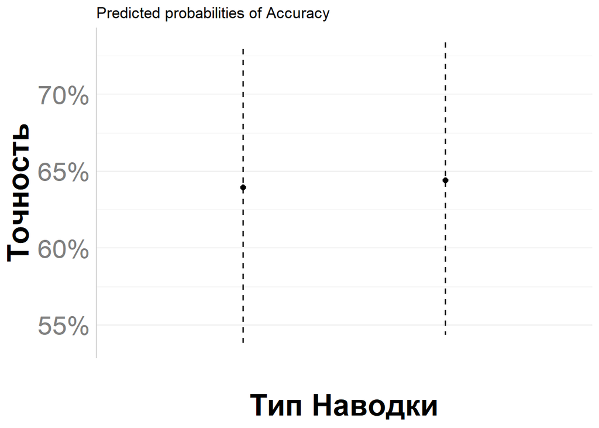

```r
plot(m) +
  labs(x = "\nТип Наводки", y = "Точность") +
  scale_x_discrete(labels = c('1' = 'Активная', '2' = 'Пассивная')) +
  theme(axis.title.x = element_text(face="bold",
                                    colour="#000000", size=25),
        axis.text.x  = element_text(vjust=0.5, size=22))+
  theme(axis.title.y = element_text(face="bold",
                                    colour="#000000", size=25),
        axis.text.y  = element_text(vjust=0.5, size=22))
```

# Гипотеза 2

Решение анаграмм с активной наводкой будет чаще сопровождаться Ага!-переживанием, чем решение анаграмм без наводки.

### Процент ага от

правильных ответов

```r
# вычисляем процент ага среди правильных ответов для каждого человека
full_data %>%
  filter(group.x == "эксп" & dropout_2h == 0) %>%
  group_by(ID, Condition) %>%
  summarise(aha = sum(Q1Aha.RESP[Q1Aha.RESP ==  1]),
            all = sum(Accuracy)) %>%
  ungroup() -> part_1_aha
```

[output not shown]

```r
part_1_aha$aha_per <-part_1_aha$aha / part_1_aha$all
print(part_1_aha)
```

```
## # A tibble: 92 × 5
##    ID    Condition   aha   all aha_per
##    <fct> <chr>     <dbl> <dbl>   <dbl>
##  1 9     1            15    20   0.75
##  2 9     2            16    23   0.696
##  3 10    1            19    23   0.826
##  4 10    2            22    30   0.733
##  5 11    1             6    19   0.316
##  6 11    2             3    15   0.2
##  7 12    1            19    28   0.679
##  8 12    2            16    37   0.432
##  9 13    1             7    20   0.35
## 10 13    2            12    22   0.545
## # ℹ 82 more rows
```

```r
# проверка на нормальность распределения
shapiro.test(part_1_aha[part_1_aha$Condition == 1, ]$aha_per - part_1_aha[part_1_aha$Condition == 2, ]$aha_per)
```

```
##
##  Shapiro-Wilk normality test
##
## data:  part_1_aha[part_1_aha$Condition == 1, ]$aha_per - part_1_aha[part_1_aha$Condition == 2, ]$aha_per
## W = 0.9649, p-value = 0.1775
```

```r
# wilx test
part_1_aha %>%
  rstatix::t_test(aha_per ~ Condition, paired = TRUE, alternative = "two.sided")
```

```
## # A tibble: 1 × 8
##   .y.     group1 group2    n1    n2 statistic    df     p
## * <chr>   <chr>  <chr>  <int> <int>     <dbl> <dbl> <dbl>
## 1 aha_per 1      2         46    46     0.816    45 0.419
```

```r
# wilcox effsize
part_1_aha %>%
  rstatix::cohens_d(aha_per ~ Condition, paired = TRUE)
```

```
## # A tibble: 1 × 7
##   .y.     group1 group2 effsize    n1    n2 magnitude
## * <chr>   <chr>  <chr>    <dbl> <int> <int> <ord>
## 1 aha_per 1      2        0.120    46    46 negligible
```

# Гипотеза 3

На втором этапе (через сутки) повторное решение анаграмм, решенных ранее на первом этапе, будет значимо быстрее, чем нерешенных. Этот мнемический выигрыш будет больше для анаграмм с активной наводкой и для анаграмм, решенных на первом этапе с Ага, – гипотеза мнемического преимущества инсайта

```r
table(full_data %>% filter(group.x == "эксп" & dropout_3h == 0)  %>%  select(Q1Aha.RESP))
```

```
## Q1Aha.RESP
##   1   2
## 843 924
```

```r
h3_data <- full_data %>% filter(group.x == "эксп" & dropout_3h == 0)
```

```r
h3_data %>%
  group_by(ID, Q1Aha.RESP) %>%
  summarize(RT = mean(Target.RT2)) -> h3_data_mean
```

[output not shown]

```r
h3_data_mean %>%
  group_by(ID) %>%
  summarize(shap_test_rt = RT[Q1Aha.RESP == 1] - RT[Q1Aha.RESP == 2])
```

```
## # A tibble: 45 × 2
##    ID    shap_test_rt
##    <fct>        <dbl>
##  1 9           -1148.
##  2 10           2449.
##  3 11           2143.
##  4 12           -533.
##  5 13            307.
##  6 17           -629.
##  7 22            816.
##  8 24          -2685.
##  9 26            737.
## 10 29          -2967.
## # ℹ 35 more rows
```

```r
model1 <- lmer(
                Target.RT2  ~ Condition + Q1Aha.RESP + (1|ID),
                h3_data,
                REML = FALSE
              )
model1 %>% summary()
```

```
## Linear mixed model fit by maximum likelihood . t-tests use Satterthwaite's
##   method [lmerModLmerTest]
## Formula: Target.RT2 ~ Condition + Q1Aha.RESP + (1 | ID)
##    Data: h3_data
##
##      AIC      BIC   logLik deviance df.resid
##  34649.7  34677.1 -17319.9  34639.7     1762
##
## Scaled residuals:
##     Min      1Q  Median      3Q     Max
## -2.2154 -0.6933 -0.2709  0.4444  4.0109
##
## Random effects:
##  Groups   Name        Variance Std.Dev.
##  ID       (Intercept)  4484489 2118
##  Residual             18014635 4244
## Number of obs: 1767, groups:  ID, 45
##
## Fixed effects:
##             Estimate Std. Error     df t value Pr(>|t|)
## (Intercept)   7619.6      480.6  174.8  15.856   <2e-16 ***
## Condition2    -224.0      203.0 1723.7  -1.104    0.270
## Q1Aha.RESP     225.4      219.5 1763.4   1.027    0.305
## ---
## Signif. codes:  0 '***' 0.001 '**' 0.01 '*' 0.05 '.' 0.1 ' ' 1
##
## Correlation of Fixed Effects:
##            (Intr) Cndtn2
## Condition2 -0.198
## Q1Aha.RESP -0.688 -0.017
```

```r
model2 <- lmer(
                Target.RT2  ~ Condition + Q1Aha.RESP + (1|Letters_y) + (1|ID),
                h3_data,
                REML = FALSE
              )
model2 %>% summary()
```

```
## Linear mixed model fit by maximum likelihood . t-tests use Satterthwaite's
##   method [lmerModLmerTest]
## Formula: Target.RT2 ~ Condition + Q1Aha.RESP + (1 | Letters_y) + (1 |      ID)
##    Data: h3_data
##
##      AIC      BIC   logLik deviance df.resid
##  34630.1  34663.0 -17309.1  34618.1     1761
##
## Scaled residuals:
##     Min      1Q  Median      3Q     Max
## -2.1233 -0.6780 -0.2658  0.4567  4.1579
##
## Random effects:
##  Groups    Name        Variance Std.Dev.
##  ID        (Intercept)  4640379 2154.2
##  Letters_y (Intercept)   320249  565.9
##  Residual              17738266 4211.7
## Number of obs: 1767, groups:  ID, 45; Letters_y, 2
##
## Fixed effects:
##             Estimate Std. Error       df t value Pr(>|t|)
## (Intercept) 7544.049    626.754    9.572  12.037 4.28e-07 ***
## Condition2  -206.383    201.421 1722.566  -1.025    0.306
## Q1Aha.RESP   279.200    218.108 1761.881   1.280    0.201
## ---
## Signif. codes:  0 '***' 0.001 '**' 0.01 '*' 0.05 '.' 0.1 ' ' 1
##
## Correlation of Fixed Effects:
##            (Intr) Cndtn2
## Condition2 -0.151
## Q1Aha.RESP -0.524 -0.016
```

```r
model3 <- lmer(
                Target.RT2  ~ Condition + Q1Aha.RESP + (1|ID) + (1|anagram_answ),
                h3_data %>% filter(Q1Aha.RESP != 3),
                REML = FALSE
              )
model3 %>% summary()
```

```
## Linear mixed model fit by maximum likelihood . t-tests use Satterthwaite's
##   method [lmerModLmerTest]
## Formula: Target.RT2 ~ Condition + Q1Aha.RESP + (1 | ID) + (1 | anagram_answ)
##    Data: h3_data %>% filter(Q1Aha.RESP != 3)
##
##      AIC      BIC   logLik deviance df.resid
##  34567.9  34600.7 -17277.9  34555.9     1761
##
## Scaled residuals:
##     Min      1Q  Median      3Q     Max
## -2.1520 -0.6632 -0.2174  0.4272  3.6452
##
## Random effects:
##  Groups       Name        Variance Std.Dev.
##  anagram_answ (Intercept)  1788050 1337
##  ID           (Intercept)  5135144 2266
##  Residual                 16216546 4027
## Number of obs: 1767, groups:  anagram_answ, 78; ID, 45
##
## Fixed effects:
##             Estimate Std. Error     df t value Pr(>|t|)
## (Intercept)   8003.4      512.4  171.9  15.620   <2e-16 ***
## Condition2    -250.7      193.8 1660.5  -1.293    0.196
## Q1Aha.RESP     184.5      213.3 1736.0   0.865    0.387
## ---
## Signif. codes:  0 '***' 0.001 '**' 0.01 '*' 0.05 '.' 0.1 ' ' 1
##
## Correlation of Fixed Effects:
##            (Intr) Cndtn2
## Condition2 -0.180
## Q1Aha.RESP -0.628 -0.014
```

```r
model4 <- lmer(
                Target.RT2  ~ Q1Aha.RESP + (1|ID) + (1|anagram_answ),
                h3_data %>% filter(Q1Aha.RESP != 3),
                REML = FALSE
              )
model4 %>% summary()
```

```
## Linear mixed model fit by maximum likelihood . t-tests use Satterthwaite's
##   method [lmerModLmerTest]
## Formula: Target.RT2 ~ Q1Aha.RESP + (1 | ID) + (1 | anagram_answ)
##    Data: h3_data %>% filter(Q1Aha.RESP != 3)
##
##      AIC      BIC   logLik deviance df.resid
##  34567.5  34594.9 -17278.8  34557.5     1762
##
## Scaled residuals:
##     Min      1Q  Median      3Q     Max
## -2.1205 -0.6665 -0.2165  0.4272  3.6383
##
## Random effects:
##  Groups       Name        Variance Std.Dev.
##  anagram_answ (Intercept)  1784088 1336
##  ID           (Intercept)  5141603 2268
##  Residual                 16233386 4029
## Number of obs: 1767, groups:  anagram_answ, 78; ID, 45
##
## Fixed effects:
##             Estimate Std. Error     df t value Pr(>|t|)
## (Intercept)   7883.7      504.2  161.2  15.636   <2e-16 ***
## Q1Aha.RESP     180.7      213.4 1736.1   0.846    0.397
## ---
## Signif. codes:  0 '***' 0.001 '**' 0.01 '*' 0.05 '.' 0.1 ' ' 1
##
## Correlation of Fixed Effects:
##            (Intr)
## Q1Aha.RESP -0.642
```

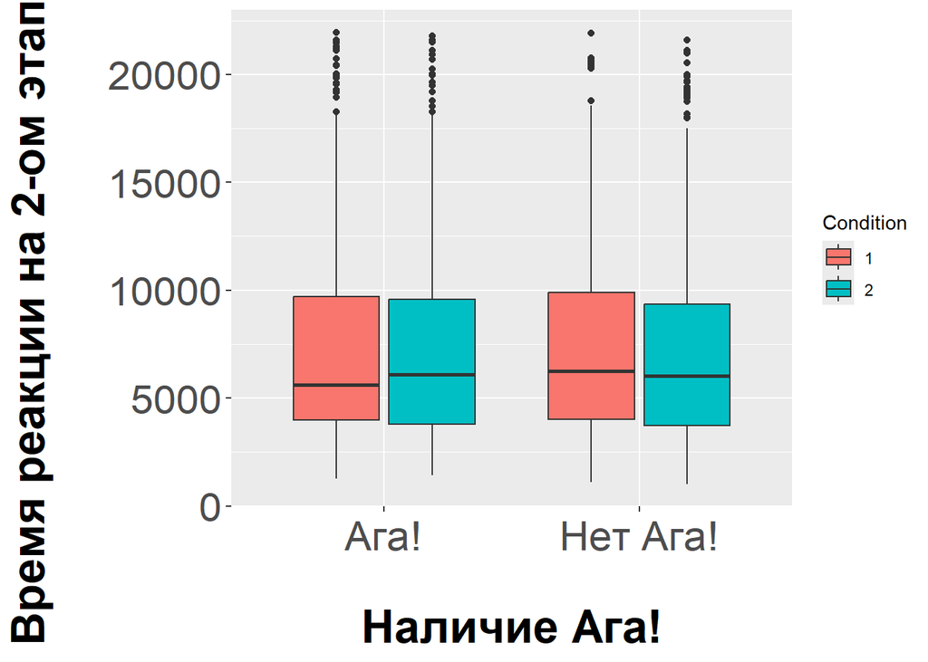

```r
h3_data %>%
  filter(Q1Aha.RESP != 3) %>%
  ggplot(aes(as.factor(Q1Aha.RESP), Target.RT2, fill = Condition)) +
  geom_boxplot()+
  xlab("\nНаличие Ага!")+
  ylab('Время реакции на 2-ом этапе (мс)\n')+
  scale_x_discrete(labels = c('1' = 'Ага!', '2' = 'Нет Ага!')) +
  theme(axis.title.x = element_text(face="bold",
                                    colour="#000000", size=25),
        axis.text.x  = element_text(vjust=0.5, size=22))+
  theme(axis.title.y = element_text(face="bold",
                                    colour="#000000", size=25),
        axis.text.y  = element_text(vjust=0.5, size=22))
```

```r
full_data$sequence.x <- as.factor(full_data$sequence.x)
```

```r
model4 <- lmer(
                Target.RT2  ~ Condition + Q1Aha.RESP + List_y + sequence.x + (1|ID) + (1|anagram_answ),
                h3_data,
                REML = FALSE)
model4 %>% summary()
```

```
## Linear mixed model fit by maximum likelihood . t-tests use Satterthwaite's
##   method [lmerModLmerTest]
## Formula: Target.RT2 ~ Condition + Q1Aha.RESP + List_y + sequence.x + (1 |
##     ID) + (1 | anagram_answ)
##    Data: h3_data
##
##      AIC      BIC   logLik deviance df.resid
##  34561.8  34605.6 -17272.9  34545.8     1759
##
## Scaled residuals:
##     Min      1Q  Median      3Q     Max
## -2.1572 -0.6643 -0.2199  0.4255  3.6585
##
## Random effects:
##  Groups       Name        Variance Std.Dev.
##  anagram_answ (Intercept)  1782163 1335
##  ID           (Intercept)  3991662 1998
##  Residual                 16218956 4027
## Number of obs: 1767, groups:  anagram_answ, 78; ID, 45
##
## Fixed effects:
##             Estimate Std. Error       df t value Pr(>|t|)
## (Intercept) 4861.595   1089.036   53.621   4.464 4.17e-05 ***
## Condition2  -248.721    193.829 1660.126  -1.283  0.19960
## Q1Aha.RESP   181.748    213.056 1739.619   0.853  0.39375
## List_y2      144.658    635.142   42.440   0.228  0.82093
## sequence.x    14.166      4.211   42.400   3.364  0.00164 **
## ---
## Signif. codes:  0 '***' 0.001 '**' 0.01 '*' 0.05 '.' 0.1 ' ' 1
##
## Correlation of Fixed Effects:
##            (Intr) Cndtn2 Q1A.RE Lst_y2
## Condition2 -0.085
## Q1Aha.RESP -0.308 -0.015
## List_y2    -0.319 -0.014  0.034
## sequence.x -0.853  0.005  0.005  0.057
```

```r
model4 <- update(model4, . ~ . -List_y)
model4 %>% summary()
```

```
## Linear mixed model fit by maximum likelihood . t-tests use Satterthwaite's
##   method [lmerModLmerTest]
## Formula: Target.RT2 ~ Condition + Q1Aha.RESP + sequence.x + (1 | ID) +
##     (1 | anagram_answ)
##    Data: h3_data
##
##      AIC      BIC   logLik deviance df.resid
##  34559.8  34598.1 -17272.9  34545.8     1760
##
## Scaled residuals:
##     Min      1Q  Median      3Q     Max
## -2.1547 -0.6658 -0.2189  0.4265  3.6597
##
## Random effects:
##  Groups       Name        Variance Std.Dev.
##  anagram_answ (Intercept)  1782443 1335
##  ID           (Intercept)  3997379 1999
##  Residual                 16218825 4027
## Number of obs: 1767, groups:  anagram_answ, 78; ID, 45
##
## Fixed effects:
##             Estimate Std. Error       df t value Pr(>|t|)
## (Intercept) 4940.681   1032.714   54.639   4.784 1.34e-05 ***
## Condition2  -248.091    193.809 1660.863  -1.280  0.20069
## Q1Aha.RESP   180.152    212.937 1740.961   0.846  0.39765
## sequence.x    14.112      4.207   42.484   3.354  0.00168 **
## ---
## Signif. codes:  0 '***' 0.001 '**' 0.01 '*' 0.05 '.' 0.1 ' ' 1
##
## Correlation of Fixed Effects:
##            (Intr) Cndtn2 Q1A.RE
## Condition2 -0.094
## Q1Aha.RESP -0.314 -0.014
## sequence.x -0.882  0.006  0.003
```

```r
model4 <- update(model4, . ~ . -Condition -sequence.x + Condition:sequence.x)
#model4 <- update(model4, . ~ . -sequence.x + (1|sequence.x))
model4 %>% summary()
```

```
## Linear mixed model fit by maximum likelihood . t-tests use Satterthwaite's
##   method [lmerModLmerTest]
## Formula:
## Target.RT2 ~ Q1Aha.RESP + (1 | ID) + (1 | anagram_answ) + Condition:sequence.x
##    Data: h3_data
##
##      AIC      BIC   logLik deviance df.resid
##  34560.7  34599.1 -17273.4  34546.7     1760
##
## Scaled residuals:
##     Min      1Q  Median      3Q     Max
## -2.1510 -0.6647 -0.2215  0.4278  3.6386
##
## Random effects:
##  Groups       Name        Variance Std.Dev.
##  anagram_answ (Intercept)  1782057 1335
##  ID           (Intercept)  3995524 1999
##  Residual                 16228133 4028
## Number of obs: 1767, groups:  anagram_answ, 78; ID, 45
##
## Fixed effects:
##                       Estimate Std. Error       df t value Pr(>|t|)
## (Intercept)           4813.483   1027.971   53.671   4.683 1.97e-05 ***
## Q1Aha.RESP             179.611    213.011 1740.982   0.843  0.39923
## Condition1:sequence.x   14.496      4.227   43.330   3.429  0.00134 **
## Condition2:sequence.x   13.762      4.231   43.465   3.253  0.00221 **
## ---
## Signif. codes:  0 '***' 0.001 '**' 0.01 '*' 0.05 '.' 0.1 ' ' 1
##
## Correlation of Fixed Effects:
##             (Intr) Q1A.RE Cnd1:.
## Q1Aha.RESP  -0.317
## Cndtn1:sqn. -0.881  0.005
## Cndtn2:sqn. -0.880  0.001  0.979
```

```r
model4 <- update(model4, . ~ . -Condition:sequence.x + (1|sequence.x) + Condition)
model4 %>% summary()
```

```
## Linear mixed model fit by maximum likelihood . t-tests use Satterthwaite's
##   method [lmerModLmerTest]
## Formula: Target.RT2 ~ Q1Aha.RESP + (1 | ID) + (1 | anagram_answ) + (1 |
##     sequence.x) + Condition
##    Data: h3_data
##
##      AIC      BIC   logLik deviance df.resid
##  34568.0  34606.3 -17277.0  34554.0     1760
##
## Scaled residuals:
##     Min      1Q  Median      3Q     Max
## -2.1501 -0.6635 -0.2161  0.4221  3.6575
##
## Random effects:
##  Groups       Name        Variance Std.Dev.
##  anagram_answ (Intercept)  1793900 1339.4
##  ID           (Intercept)  4344699 2084.4
##  sequence.x   (Intercept)   797705  893.1
##  Residual                 16216844 4027.0
## Number of obs: 1767, groups:  anagram_answ, 78; ID, 45; sequence.x, 6
##
## Fixed effects:
##             Estimate Std. Error      df t value Pr(>|t|)
## (Intercept)  8032.69     615.21   14.05  13.057 3.02e-09 ***
## Q1Aha.RESP    174.28     213.17 1736.70   0.818    0.414
## Condition2   -250.93     193.82 1660.45  -1.295    0.196
## ---
## Signif. codes:  0 '***' 0.001 '**' 0.01 '*' 0.05 '.' 0.1 ' ' 1
##
## Correlation of Fixed Effects:
##            (Intr) Q1A.RE
## Q1Aha.RESP -0.522
## Condition2 -0.150 -0.014
```

```r
model5 <- lmer(
                Target.RT2  ~ Q1Aha.RESP + (1|ID) + (1|anagram_answ),
                h3_data,
                REML = FALSE
              )
model3 %>% summary()
```

```
## Linear mixed model fit by maximum likelihood . t-tests use Satterthwaite's
##   method [lmerModLmerTest]
## Formula: Target.RT2 ~ Condition + Q1Aha.RESP + (1 | ID) + (1 | anagram_answ)
##    Data: h3_data %>% filter(Q1Aha.RESP != 3)
##
##      AIC      BIC   logLik deviance df.resid
##  34567.9  34600.7 -17277.9  34555.9     1761
##
## Scaled residuals:
##     Min      1Q  Median      3Q     Max
## -2.1520 -0.6632 -0.2174  0.4272  3.6452
##
## Random effects:
##  Groups       Name        Variance Std.Dev.
##  anagram_answ (Intercept)  1788050 1337
##  ID           (Intercept)  5135144 2266
##  Residual                 16216546 4027
## Number of obs: 1767, groups:  anagram_answ, 78; ID, 45
##
## Fixed effects:
##             Estimate Std. Error     df t value Pr(>|t|)
## (Intercept)   8003.4      512.4  171.9  15.620   <2e-16 ***
## Condition2    -250.7      193.8 1660.5  -1.293    0.196
## Q1Aha.RESP     184.5      213.3 1736.0   0.865    0.387
## ---
## Signif. codes:  0 '***' 0.001 '**' 0.01 '*' 0.05 '.' 0.1 ' ' 1
##
## Correlation of Fixed Effects:
##            (Intr) Cndtn2
## Condition2 -0.180
## Q1Aha.RESP -0.628 -0.014
```

```r
# сравнение моделей между собой
anova(model1, model2)
```

```
## Data: h3_data
## Models:
## model1: Target.RT2 ~ Condition + Q1Aha.RESP + (1 | ID)
## model2: Target.RT2 ~ Condition + Q1Aha.RESP + (1 | Letters_y) + (1 | ID)
##        npar   AIC   BIC logLik deviance  Chisq Df Pr(>Chisq)
## model1    5 34650 34677 -17320    34640
## model2    6 34630 34663 -17309    34618 21.619  1  3.325e-06 ***
## ---
## Signif. codes:  0 '***' 0.001 '**' 0.01 '*' 0.05 '.' 0.1 ' ' 1
```

```r
#anova(model1, model3)
#anova(model2, model3)
#anova(model2, model4)
#anova(model3, model4)
```

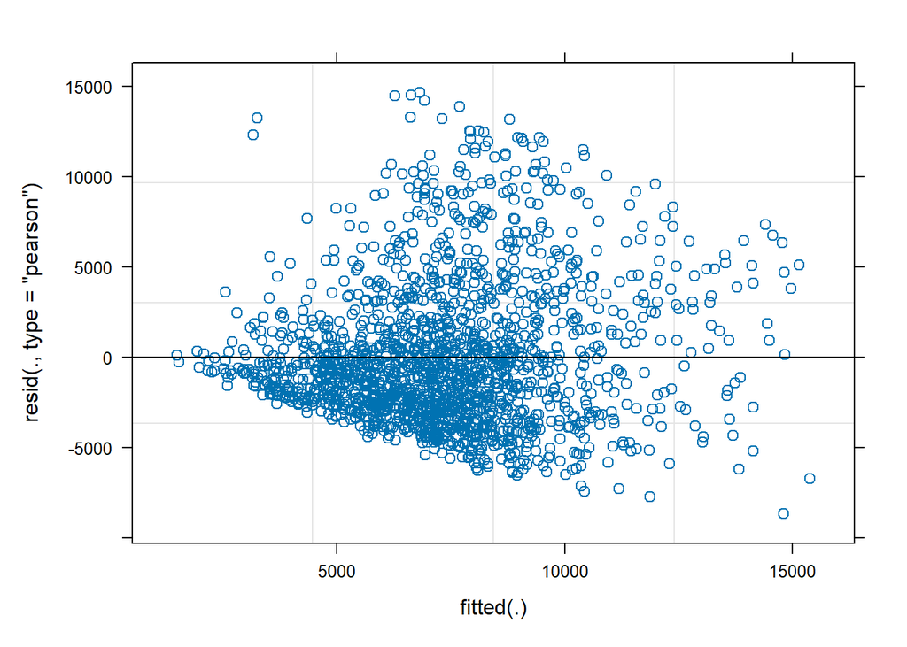

```r
h3_data$pred <- predict(model3, type = "response")
#ggplot(h3_data,aes(x = prob_counter2)) +
#    geom_point(aes(y = Target.RT2)) +
#    geom_line(aes(y = pred), color="red", alpha = 0.5) +
#    facet_grid(~Condition, scales = "free",  space='free')
plot(model3)
```

# Гипотеза 4

На втором этапе отчеты об отвергнутых версиях будут реже содержать слова-наводки (интрузии), если на первом этапе анаграмма провоцировала эффект фиксированности, но была решена, по сравнению с анаграммами, которые не были решены и даже с анаграммами без фиксированности, которые были решены, – гипотеза забывания, вызванного переструктурированием

```r
h4_data <- full_data %>% filter(group.x == "эксп")
```

```r
h4_data %>%
  group_by(ID, Condition, Accuracy) %>%
  summarise(intr_per = sum(intrusion) / length(intrusion) * 100,
            intr_count = sum(intrusion),
            prob_count = n()) %>%
  ungroup() -> h4_data_mean_id
```

RMANOVA - с усреднением по челику

```r
model1 <- lmer(intr_per ~ Condition*Accuracy + (1|ID), h4_data_mean_id)
summary(model1)
```

```
## Linear mixed model fit by REML. t-tests use Satterthwaite's method [
## lmerModLmerTest]
## Formula: intr_per ~ Condition * Accuracy + (1 | ID)
##    Data: h4_data_mean_id
##
## REML criterion at convergence: 1624.3
##
## Scaled residuals:
##      Min       1Q   Median       3Q      Max
## -2.23792 -0.58715 -0.07949  0.49883  2.94238
##
## Random effects:
##  Groups   Name        Variance Std.Dev.
##  ID       (Intercept) 38.38    6.195
##  Residual             90.00    9.487
## Number of obs: 216, groups:  ID, 54
##
## Fixed effects:
##                     Estimate Std. Error      df t value Pr(>|t|)
## (Intercept)           25.895      1.542 167.182  16.795  < 2e-16 ***
## Condition2            -4.995      1.826 159.000  -2.736  0.00693 **
## Accuracy              -9.435      1.826 159.000  -5.168 7.02e-07 ***
## Condition2:Accuracy    5.296      2.582 159.000   2.051  0.04188 *
## ---
## Signif. codes:  0 '***' 0.001 '**' 0.01 '*' 0.05 '.' 0.1 ' ' 1
##
## Correlation of Fixed Effects:
##             (Intr) Cndtn2 Accrcy
## Condition2  -0.592
## Accuracy    -0.592  0.500
## Cndtn2:Accr  0.419 -0.707 -0.707
```

## График (усреднение по человеку)

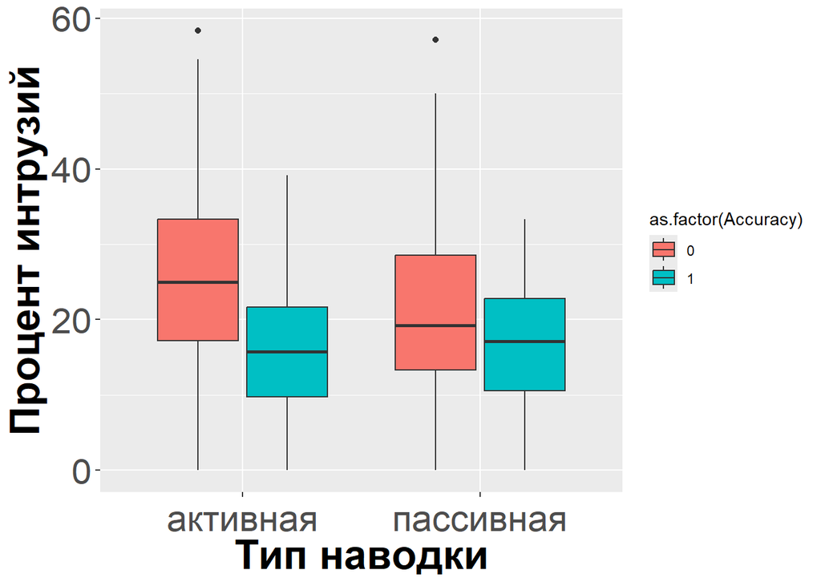

```r
h4_data_mean_id %>%
  ggplot(aes(as.factor(Condition), intr_per, fill = as.factor(Accuracy))) +
  geom_boxplot()+
  xlab("Тип наводки")+
  ylab('Процент интрузий')+
  scale_x_discrete(labels = c('1' = 'активная', '2' = 'пассивная')) +
  theme(axis.title.x = element_text(face="bold",
                                    colour="#000000", size=25),
        axis.text.x  = element_text(vjust=0.5, size=22))+
  theme(axis.title.y = element_text(face="bold",
                                    colour="#000000", size=25),
        axis.text.y  = element_text(vjust=0.5, size=22))
```

```r
h4_data %>%
  group_by(anagram_answ, Condition, Accuracy) %>%
  summarise(intr_per = sum(intrusion) / length(intrusion) * 100,
            intr_count = sum(intrusion),
            prob_count = n()) %>%
  ungroup() -> h4_mean_anagram
model2 <- lmer(intr_per ~ Condition*Accuracy + (1|anagram_answ), h4_mean_anagram)
summary(model2)
```

```
## Linear mixed model fit by REML. t-tests use Satterthwaite's method [
## lmerModLmerTest]
## Formula: intr_per ~ Condition * Accuracy + (1 | anagram_answ)
##    Data: h4_mean_anagram
##
## REML criterion at convergence: 2553.9
##
## Scaled residuals:
##     Min      1Q  Median      3Q     Max
## -2.2746 -0.6283 -0.0806  0.5192  3.3160
##
## Random effects:
##  Groups       Name        Variance Std.Dev.
##  anagram_answ (Intercept) 210.7    14.51
##  Residual                 139.0    11.79
## Number of obs: 311, groups:  anagram_answ, 78
##
## Fixed effects:
##                     Estimate Std. Error      df t value Pr(>|t|)
## (Intercept)           24.698      2.117 147.320  11.664  < 2e-16 ***
## Condition2            -4.137      1.896 230.199  -2.182   0.0301 *
## Accuracy              -7.919      1.888 230.028  -4.194 3.91e-05 ***
## Condition2:Accuracy    4.342      2.676 230.114   1.623   0.1060
## ---
## Signif. codes:  0 '***' 0.001 '**' 0.01 '*' 0.05 '.' 0.1 ' ' 1
##
## Correlation of Fixed Effects:
##             (Intr) Cndtn2 Accrcy
## Condition2  -0.444
## Accuracy    -0.446  0.498
## Cndtn2:Accr  0.315 -0.709 -0.706
```

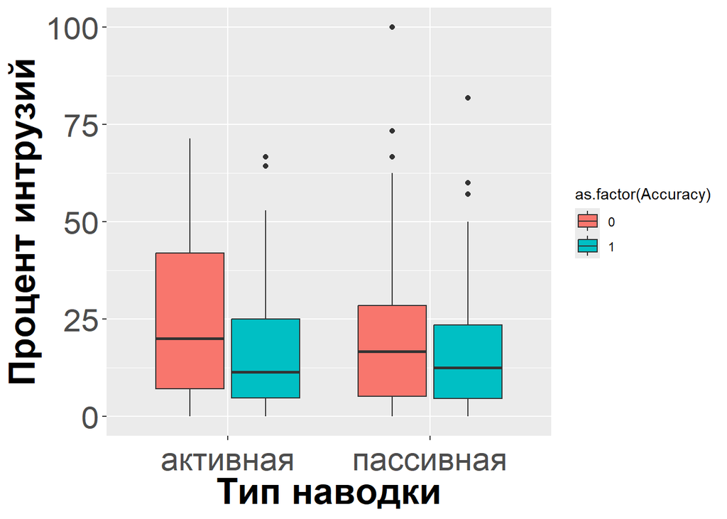

```r
h4_mean_anagram %>%
  ggplot(aes(as.factor(Condition), intr_per, fill = as.factor(Accuracy))) +
  geom_boxplot()+
  xlab("Тип наводки")+
  ylab('Процент интрузий')+
  scale_x_discrete(labels = c('1' = 'активная', '2' = 'пассивная')) +
  theme(axis.title.x = element_text(face="bold",
                                    colour="#000000", size=25),
        axis.text.x  = element_text(vjust=0.5, size=22))+
  theme(axis.title.y = element_text(face="bold",
                                    colour="#000000", size=25),
        axis.text.y  = element_text(vjust=0.5, size=22))
```

```r
# t.test(h4_data_mean$tg_intr_per, h4_data_mean$notg_intr_per, paired = TRUE)
```

```r
h4_data %>%
  group_by(ID, Condition, Accuracy, type_intrusion, ) %>%
  summarise(intr_per = round((n() / BASE_COUNT_PROB) * 100), 0) %>%
  filter(type_intrusion != 0) %>%
  select(-type_intrusion) %>%
  ungroup() -> h4_data_mean
h4_data_mean %>%
  left_join(
    h4_data_mean %>%
      group_by(ID) %>%
      summarise(n = n())
  ) -> h4_data_mean
  h4_data_mean <- h4_data_mean %>% filter(n == 3)
```

Смешанные модели

```r
h4_data <- full_data %>% filter(group.x == "эксп")
```

```r
h4_data$is_intrusion <- as.numeric(h4_data$type_intrusion != 0)
```

```r
model2 <- glmer(
                is_intrusion ~ Condition*Accuracy + (1|ID),
                h4_data,
                family = binomial)
summary(model2)
```

```
## Generalized linear mixed model fit by maximum likelihood (Laplace
##   Approximation) [glmerMod]
##  Family: binomial  ( logit )
## Formula: is_intrusion ~ Condition * Accuracy + (1 | ID)
##    Data: h4_data
##
##      AIC      BIC   logLik deviance df.resid
##   4076.4   4108.1  -2033.2   4066.4     4207
##
## Scaled residuals:
##     Min      1Q  Median      3Q     Max
## -0.8026 -0.5108 -0.4410 -0.3679  3.1703
##
## Random effects:
##  Groups Name        Variance Std.Dev.
##  ID     (Intercept) 0.1513   0.3889
## Number of obs: 4212, groups:  ID, 54
##
## Fixed effects:
##                     Estimate Std. Error z value Pr(>|z|)
## (Intercept)         -1.08251    0.09716 -11.142  < 2e-16 ***
## Condition2          -0.30040    0.11873  -2.530   0.0114 *
## Accuracy            -0.57549    0.11196  -5.140 2.75e-07 ***
## Condition2:Accuracy  0.30878    0.15984   1.932   0.0534 .
## ---
## Signif. codes:  0 '***' 0.001 '**' 0.01 '*' 0.05 '.' 0.1 ' ' 1
##
## Correlation of Fixed Effects:
##             (Intr) Cndtn2 Accrcy
## Condition2  -0.559
## Accuracy    -0.609  0.486
## Cndtn2:Accr  0.416 -0.746 -0.679
```

```r
model3 <- glmer(
                is_intrusion ~ Condition*Accuracy + (1|ID) + (1|anagram_answ),
                h4_data,
                family = binomial)
summary(model3)
```

```
## Generalized linear mixed model fit by maximum likelihood (Laplace
##   Approximation) [glmerMod]
##  Family: binomial  ( logit )
## Formula: is_intrusion ~ Condition * Accuracy + (1 | ID) + (1 | anagram_answ)
##    Data: h4_data
##
##      AIC      BIC   logLik deviance df.resid
##   3669.6   3707.7  -1828.8   3657.6     4206
##
## Scaled residuals:
##     Min      1Q  Median      3Q     Max
## -2.1892 -0.4742 -0.3164 -0.1901  6.5009
##
## Random effects:
##  Groups       Name        Variance Std.Dev.
##  anagram_answ (Intercept) 1.1224   1.0594
##  ID           (Intercept) 0.2288   0.4784
## Number of obs: 4212, groups:  anagram_answ, 78; ID, 54
##
## Fixed effects:
##                     Estimate Std. Error z value Pr(>|z|)
## (Intercept)          -1.3364     0.1663  -8.038 9.13e-16 ***
## Condition2           -0.3022     0.1291  -2.341   0.0193 *
## Accuracy             -0.6560     0.1272  -5.158 2.49e-07 ***
## Condition2:Accuracy   0.2867     0.1734   1.654   0.0982 .
## ---
## Signif. codes:  0 '***' 0.001 '**' 0.01 '*' 0.05 '.' 0.1 ' ' 1
##
## Correlation of Fixed Effects:
##             (Intr) Cndtn2 Accrcy
## Condition2  -0.357
## Accuracy    -0.408  0.474
## Cndtn2:Accr  0.270 -0.753 -0.653
```

```r
anova(model2, model3)
```

```
## Data: h4_data
## Models:
## model2: is_intrusion ~ Condition * Accuracy + (1 | ID)
## model3: is_intrusion ~ Condition * Accuracy + (1 | ID) + (1 | anagram_answ)
##        npar    AIC    BIC  logLik deviance  Chisq Df Pr(>Chisq)
## model2    5 4076.4 4108.1 -2033.2   4066.4
## model3    6 3669.6 3707.7 -1828.8   3657.6 408.76  1  < 2.2e-16 ***
## ---
## Signif. codes:  0 '***' 0.001 '**' 0.01 '*' 0.05 '.' 0.1 ' ' 1
```

```r
model4 <- glmer(
                is_intrusion ~ Condition+Accuracy + (1|ID) + (1|anagram_answ),
                h4_data,
                family = binomial)
summary(model4)
```

```
## Generalized linear mixed model fit by maximum likelihood (Laplace
##   Approximation) [glmerMod]
##  Family: binomial  ( logit )
## Formula: is_intrusion ~ Condition + Accuracy + (1 | ID) + (1 | anagram_answ)
##    Data: h4_data
##
##      AIC      BIC   logLik deviance df.resid
##   3670.3   3702.0  -1830.1   3660.3     4207
##
## Scaled residuals:
##     Min      1Q  Median      3Q     Max
## -2.1340 -0.4745 -0.3170 -0.1900  6.2758
##
## Random effects:
##  Groups       Name        Variance Std.Dev.
##  anagram_answ (Intercept) 1.1230   1.0597
##  ID           (Intercept) 0.2291   0.4787
## Number of obs: 4212, groups:  anagram_answ, 78; ID, 54
##
## Fixed effects:
##             Estimate Std. Error z value Pr(>|z|)
## (Intercept) -1.41173    0.16041  -8.801  < 2e-16 ***
## Condition2  -0.14206    0.08489  -1.674   0.0942 .
## Accuracy    -0.51888    0.09626  -5.390 7.04e-08 ***
## ---
## Signif. codes:  0 '***' 0.001 '**' 0.01 '*' 0.05 '.' 0.1 ' ' 1
##
## Correlation of Fixed Effects:
##            (Intr) Cndtn2
## Condition2 -0.251
## Accuracy   -0.324 -0.009
```

```r
anova(model3, model4)
```

```
## Data: h4_data
## Models:
## model4: is_intrusion ~ Condition + Accuracy + (1 | ID) + (1 | anagram_answ)
## model3: is_intrusion ~ Condition * Accuracy + (1 | ID) + (1 | anagram_answ)
##        npar    AIC    BIC  logLik deviance Chisq Df Pr(>Chisq)
## model4    5 3670.3 3702.0 -1830.1   3660.3
## model3    6 3669.6 3707.7 -1828.8   3657.6  2.66  1     0.1029
```

```r
model5 <- glmer(
                is_intrusion ~ Accuracy + (1|ID) + (1|anagram_answ),
                h4_data,
                family = binomial)
summary(model5)
```

```
## Generalized linear mixed model fit by maximum likelihood (Laplace
##   Approximation) [glmerMod]
##  Family: binomial  ( logit )
## Formula: is_intrusion ~ Accuracy + (1 | ID) + (1 | anagram_answ)
##    Data: h4_data
##
##      AIC      BIC   logLik deviance df.resid
##   3671.0   3696.4  -1831.5   3663.0     4208
##
## Scaled residuals:
##     Min      1Q  Median      3Q     Max
## -2.0583 -0.4756 -0.3164 -0.1906  6.5096
##
## Random effects:
##  Groups       Name        Variance Std.Dev.
##  anagram_answ (Intercept) 1.1214   1.0589
##  ID           (Intercept) 0.2291   0.4787
## Number of obs: 4212, groups:  anagram_answ, 78; ID, 54
##
## Fixed effects:
##             Estimate Std. Error z value Pr(>|z|)
## (Intercept) -1.48028    0.15520  -9.538  < 2e-16 ***
## Accuracy    -0.52088    0.09621  -5.414 6.16e-08 ***
## ---
## Signif. codes:  0 '***' 0.001 '**' 0.01 '*' 0.05 '.' 0.1 ' ' 1
##
## Correlation of Fixed Effects:
##          (Intr)
## Accuracy -0.337
```

```r
anova(model3, model5)
```

```
## Data: h4_data
## Models:
## model5: is_intrusion ~ Accuracy + (1 | ID) + (1 | anagram_answ)
## model3: is_intrusion ~ Condition * Accuracy + (1 | ID) + (1 | anagram_answ)
##        npar    AIC    BIC  logLik deviance  Chisq Df Pr(>Chisq)
## model5    4 3671.0 3696.4 -1831.5   3663.0
## model3    6 3669.6 3707.7 -1828.8   3657.6 5.3821  2    0.06781 .
## ---
## Signif. codes:  0 '***' 0.001 '**' 0.01 '*' 0.05 '.' 0.1 ' ' 1
```

```r
#install.packages('Rmisc')
#install.packages('sjPlot')
#install.packages('effects')
```

```r
# library(Rmisc)
# library(sjPlot)
# library(effects)
```

```r
# # Создаем датафрейм с предсказанными значениями
# h4_data$predicted_prob <- predict(model1, type = "response")
#
# # Визуализация предсказанных вероятностей
# ggplot(h4_data, aes(x = fix, y = predicted_prob)) +
#   geom_boxplot(aes(fill = Condition)) +
#   labs(
#     title = "Предсказанные вероятности по условиям",
#     x = "Условие",
#     y = "Предсказанная вероятность"
#   )
```

```r
# eff <- allEffects(model)
# plot(eff)
```

Таким образом, частота интрузий зависит от правильности решения на первом этапе.

# Гипотеза 5. Мнемический выигрыш от Ага

```r
full_data %>%
  filter(group.x == "эксп" & dropout_3h == 0) %>%
  filter(Q1Aha.RESP != 3) %>%
  pivot_longer(cols = c("Target.RT_corr", "Target.RT2"), names_to="stage", values_to = "RT")  -> h5_data

h5_data$stage = as.factor(as.numeric(h5_data$stage != "Target.RT_corr") + 1)
h5_data$Q1Aha.RESP <- as.factor(h5_data$Q1Aha.RESP)
```

```r
model1 <- lmer(RT ~ Condition*stage*Q1Aha.RESP + (1|ID), h5_data, REML = TRUE)
summary(model1)
```

```
## Linear mixed model fit by REML. t-tests use Satterthwaite's method [
## lmerModLmerTest]
## Formula: RT ~ Condition * stage * Q1Aha.RESP + (1 | ID)
##    Data: h5_data
##
## REML criterion at convergence: 69532.4
##
## Scaled residuals:
##     Min      1Q  Median      3Q     Max
## -2.4017 -0.7046 -0.2765  0.4930  3.6139
##
## Random effects:
##  Groups   Name        Variance Std.Dev.
##  ID       (Intercept)  2358146 1536
##  Residual             20588513 4537
## Number of obs: 3534, groups:  ID, 45
##
## Fixed effects:
##                               Estimate Std. Error       df t value Pr(>|t|)
## (Intercept)                    9325.69     320.36   124.67  29.110  < 2e-16 ***
## Condition2                      147.06     313.60  3485.91   0.469  0.63913
## stage2                        -1655.16     310.90  3479.93  -5.324 1.08e-07 ***
## Q1Aha.RESP2                   -1013.11     314.24  3516.47  -3.224  0.00128 **
## Condition2:stage2              -177.08     442.05  3479.93  -0.401  0.68875
## Condition2:Q1Aha.RESP2         -345.73     434.63  3489.17  -0.795  0.42640
## stage2:Q1Aha.RESP2             1334.59     432.85  3479.93   3.083  0.00206 **
## Condition2:stage2:Q1Aha.RESP2   -42.63     611.32  3479.93  -0.070  0.94441
## ---
## Signif. codes:  0 '***' 0.001 '**' 0.01 '*' 0.05 '.' 0.1 ' ' 1
##
## Correlation of Fixed Effects:
##             (Intr) Cndtn2 stage2 Q1A.RE Cnd2:2 C2:Q1A s2:Q1A
## Condition2  -0.484
## stage2      -0.485  0.496
## Q1Aha.RESP2 -0.503  0.496  0.495
## Cndtn2:stg2  0.341 -0.705 -0.703 -0.348
## C2:Q1A.RESP  0.352 -0.724 -0.358 -0.697  0.509
## s2:Q1A.RESP  0.349 -0.356 -0.718 -0.689  0.505  0.498
## C2:2:Q1A.RE -0.247  0.510  0.509  0.488 -0.723 -0.703 -0.708
```

```r
model2 <- lmer(RT ~ stage*Q1Aha.RESP + (1|ID), h5_data, REML = TRUE)
summary(model2)
```

```
## Linear mixed model fit by REML. t-tests use Satterthwaite's method [
## lmerModLmerTest]
## Formula: RT ~ stage * Q1Aha.RESP + (1 | ID)
##    Data: h5_data
##
## REML criterion at convergence: 69588.2
##
## Scaled residuals:
##     Min      1Q  Median      3Q     Max
## -2.4179 -0.7110 -0.2775  0.4929  3.5660
##
## Random effects:
##  Groups   Name        Variance Std.Dev.
##  ID       (Intercept)  2351642 1534
##  Residual             20580845 4537
## Number of obs: 3534, groups:  ID, 45
##
## Fixed effects:
##                    Estimate Std. Error       df t value Pr(>|t|)
## (Intercept)         9400.18     280.05    73.58  33.566  < 2e-16 ***
## stage2             -1742.76     220.97  3483.93  -7.887 4.11e-15 ***
## Q1Aha.RESP2        -1189.11     225.41  3529.15  -5.275 1.40e-07 ***
## stage2:Q1Aha.RESP2  1310.43     305.57  3483.93   4.288 1.85e-05 ***
## ---
## Signif. codes:  0 '***' 0.001 '**' 0.01 '*' 0.05 '.' 0.1 ' ' 1
##
## Correlation of Fixed Effects:
##             (Intr) stage2 Q1A.RE
## stage2      -0.395
## Q1Aha.RESP2 -0.417  0.490
## s2:Q1A.RESP  0.285 -0.723 -0.678
```

```r
anova(model1, model2)
```

```
## refitting model(s) with ML (instead of REML)
```

```
## Data: h5_data
## Models:
## model2: RT ~ stage * Q1Aha.RESP + (1 | ID)
## model1: RT ~ Condition * stage * Q1Aha.RESP + (1 | ID)
##        npar   AIC   BIC logLik deviance  Chisq Df Pr(>Chisq)
## model2    6 69650 69687 -34819    69638
## model1   10 69656 69717 -34818    69636 2.5939  4     0.6279
```

```r
update(model2, . ~ . +(1|anagram_answ))
```

```
## Linear mixed model fit by REML ['lmerModLmerTest']
## Formula:
## RT ~ stage + Q1Aha.RESP + (1 | ID) + (1 | anagram_answ) + stage:Q1Aha.RESP
##    Data: h5_data
## REML criterion at convergence: 69452.14
## Random effects:
##  Groups       Name        Std.Dev.
##  anagram_answ (Intercept) 1221
##  ID           (Intercept) 1656
##  Residual                 4375
## Number of obs: 3534, groups:  anagram_answ, 78; ID, 45
## Fixed Effects:
##        (Intercept)              stage2         Q1Aha.RESP2  stage2:Q1Aha.RESP2
##               9716               -1743               -1200                1310
```

```r
summary(model2)
```

```
## Linear mixed model fit by REML. t-tests use Satterthwaite's method [
## lmerModLmerTest]
## Formula: RT ~ stage * Q1Aha.RESP + (1 | ID)
##    Data: h5_data
##
## REML criterion at convergence: 69588.2
##
## Scaled residuals:
##     Min      1Q  Median      3Q     Max
## -2.4179 -0.7110 -0.2775  0.4929  3.5660
##
## Random effects:
##  Groups   Name        Variance Std.Dev.
##  ID       (Intercept)  2351642 1534
##  Residual             20580845 4537
## Number of obs: 3534, groups:  ID, 45
##
## Fixed effects:
##                    Estimate Std. Error       df t value Pr(>|t|)
## (Intercept)         9400.18     280.05    73.58  33.566  < 2e-16 ***
## stage2             -1742.76     220.97  3483.93  -7.887 4.11e-15 ***
## Q1Aha.RESP2        -1189.11     225.41  3529.15  -5.275 1.40e-07 ***
## stage2:Q1Aha.RESP2  1310.43     305.57  3483.93   4.288 1.85e-05 ***
## ---
## Signif. codes:  0 '***' 0.001 '**' 0.01 '*' 0.05 '.' 0.1 ' ' 1
##
## Correlation of Fixed Effects:
##             (Intr) stage2 Q1A.RE
## stage2      -0.395
## Q1Aha.RESP2 -0.417  0.490
## s2:Q1A.RESP  0.285 -0.723 -0.678
```

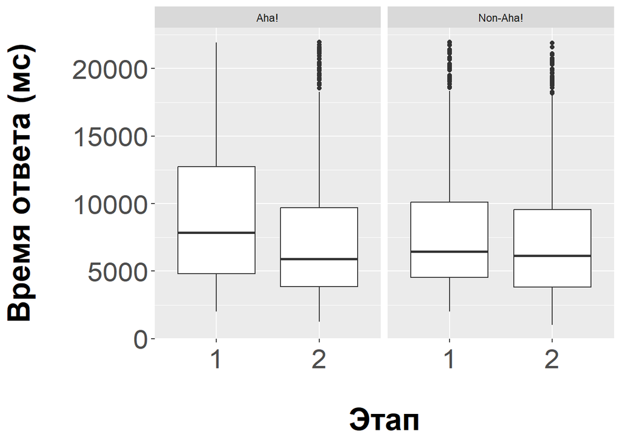

```r
aha_temp <- list('1' = 'Aha!', '2' = 'Non-Aha!')

labeller_temp <- function(variable,value){
  return(aha_temp[value])
}

h5_data %>%
  ggplot(aes(stage, RT)) +
  facet_grid(~Q1Aha.RESP, labeller=labeller_temp) +
  geom_boxplot() +
  xlab("\nЭтап") +
  ylab("Время ответа (мс)\n")+
  theme(axis.title.x = element_text(face="bold",
                                    colour="#000000", size=25),
        axis.text.x  = element_text(vjust=0.5, size=22))+
  theme(axis.title.y = element_text(face="bold",
                                    colour="#000000", size=25),
        axis.text.y  = element_text(vjust=0.5, size=22))
```

```r
h5_data$Q1Aha.RESP <- as.factor(h5_data$Q1Aha.RESP)
h5_data$stage <- as.factor(h5_data$stage)

aggregate(RT ~ Q1Aha.RESP*stage, FUN = mean, h5_data)
```

```
##   Q1Aha.RESP stage       RT
## 1          1     1 9102.788
## 2          2     1 7828.444
## 3          1     2 7360.030
## 4          2     2 7396.113
```

```r
full_data %>%
  filter(group.x == "эксп" & dropout_3h == 0) %>%
  mutate(diff = Target.RT2 - Target.RT_corr) -> h5_data_2
```

```r
model1 <- lmer(diff ~ Q1Aha.RESP + (1|ID), h5_data_2, REML = TRUE)
summary(model1)
```

```
## Linear mixed model fit by REML. t-tests use Satterthwaite's method [
## lmerModLmerTest]
## Formula: diff ~ Q1Aha.RESP + (1 | ID)
##    Data: h5_data_2
##
## REML criterion at convergence: 35673.4
##
## Scaled residuals:
##     Min      1Q  Median      3Q     Max
## -3.0905 -0.5407  0.0086  0.5173  3.7154
##
## Random effects:
##  Groups   Name        Variance Std.Dev.
##  ID       (Intercept)  3045637 1745
##  Residual             33574281 5794
## Number of obs: 1767, groups:  ID, 45
##
## Fixed effects:
##             Estimate Std. Error      df t value Pr(>|t|)
## (Intercept)  -3080.9      538.9   347.7  -5.717 2.34e-08 ***
## Q1Aha.RESP    1465.4      296.0  1743.1   4.951 8.08e-07 ***
## ---
## Signif. codes:  0 '***' 0.001 '**' 0.01 '*' 0.05 '.' 0.1 ' ' 1
##
## Correlation of Fixed Effects:
##            (Intr)
## Q1Aha.RESP -0.833
```

```r
table(h5_data$Q1Aha.RESP)
```

```
##
##    1    2
## 1686 1848
```